# ARG-NLI Data Analysis Hard Threshold

```r
library(lme4)
library(broom.mixed)
library(dplyr)
```

# Data Loading and Preparation

In this section, we load in the data, transform all relevant character vectors to factors, and clean up NAs in the data.

```r
hard_threshold <- read.csv("D:\\OneDrive - University of Dundee\\PhD\\ARG-NLI_project\\feature_analysis\\automatic\\new_features\\corpus_threshold_hard_0.999_standardised_and_log_scaled.csv")
```

```r
factor_vars <- c(
  "seg1_has_deduction", "seg2_has_deduction",
  "seg1_has_refutation", "seg2_has_refutation",
  "seg1_has_condition", "seg2_has_condition",
  "seg1_has_explanation", "seg2_has_explanation",
  "seg1_has_adverb_of_emphasis", "seg2_has_adverb_of_emphasis",
  "seg1_has_justification", "seg2_has_justification",
  "seg1_has_modal_verbs", "seg2_has_modal_verbs",
  "seg1_senti", "seg2_senti", "CorpusID"
)

hard_threshold[factor_vars] <- lapply(hard_threshold[factor_vars], function(x) as.factor(as.character(x)))
```

```r
is_entailment <- "is_entailment"
is_contradiction <- "is_contradiction"
is_neutral <- "is_neutral"
is_support <- "is_support"
is_attack <- "is_attack"
support_is_entailment <- "arg_nli_support"
attack_is_contradiction <- "arg_nli_attack"

outcome <- is_entailment
```

```r
# Drop rows with any missing values
hard_threshold_complete <- hard_threshold[complete.cases(hard_threshold), ]
```

# Step 1: Block model fitting

In the first step, we split up the entire set of features into 8 linguistically motivated blocks and fit one model for each block that includes these features plus the number of tokens as a baseline feature. The gain in AIC is then compared for each block with the baseline model with the number of tokens as the only feature. Since we cannot guarantee that there is no interdependence introduced by the different corpora, the corpus is always used as a random effect.

```r
blocks <- list(
  lexical_markers = c("seg1_has_deduction", "seg2_has_deduction",
                      "seg1_has_refutation", "seg2_has_refutation",
                      "seg1_has_condition", "seg2_has_condition",
                      "seg1_has_explanation", "seg2_has_explanation",
                      "seg1_has_adverb_of_emphasis", "seg2_has_adverb_of_emphasis",
                      "seg1_has_justification", "seg2_has_justification",
                      "seg1_has_modal_verbs", "seg2_has_modal_verbs"),
  lexical_sim = c("tfidf_cosine_similarity"),
  semantic = c("cosine_similarity"),
  structure = c("seg1_sentence_length_mean", "seg2_sentence_length_mean"),
  #                     "seg1_n_tokens", "seg2_n_tokens"),
  syntactic = c("seg1_dependency_distance_mean", "seg2_dependency_distance_mean",
                "seg1_prop_adjacent_dependency_relation_mean", "seg2_prop_adjacent_dependency_relation_mean",
                "seg1_avg_subclauses", "seg2_avg_subclauses",
                "seg1_avg_tree_depth", "seg2_avg_tree_depth"),
  perplexity = c("seg1_perplexity", "seg2_perplexity", #"seg1_given_seg2_perplexity",
                 "seg2_given_seg1_perplexity"),
  indirectness = c("seg1_impScore", "seg2_impScore", "prag_distance"),
  sentiment = c("seg1_senti", "seg2_senti")
)

interactions <- list(
  c("seg1_avg_subclauses", "seg1_sentence_length_mean"),
  c("seg2_avg_subclauses", "seg2_sentence_length_mean"),
  c("seg1_avg_tree_depth", "seg1_avg_subclauses"),
  c("seg2_avg_tree_depth", "seg2_avg_subclauses"),
  c("seg1_avg_tree_depth", "seg1_sentence_length_mean"),
  c("seg2_avg_tree_depth", "seg2_sentence_length_mean"),
  c("seg1_dependency_distance_mean", "seg1_sentence_length_mean"),
  c("seg2_sentence_length_mean", "seg2_dependency_distance_mean"),
  c("seg1_dependency_distance_mean", "seg1_avg_subclauses"),
  c("prag_distance", "cosine_similarity"),
  c("tfidf_cosine_similarity", "cosine_similarity"),
  c("seg2_dependency_distance_mean", "seg2_avg_subclauses"),
  c("seg2_sentence_length_mean", "seg2_n_tokens"),
  c("seg2_avg_subclauses", "seg2_n_tokens"),
  c("seg1_avg_subclauses", "seg1_n_tokens"),
  c("seg1_sentence_length_mean", "seg1_n_tokens"),
  c("seg2_dependency_distance_mean", "seg2_n_tokens"),
  c("tfidf_cosine_similarity", "prag_distance"),
  c("seg1_avg_tree_depth", "seg1_dependency_distance_mean"),
  c("seg2_avg_tree_depth", "seg2_n_tokens"),
  c("seg1_dependency_distance_mean", "seg1_n_tokens"),
  c("seg1_avg_tree_depth", "seg1_n_tokens"),
  c("seg2_dependency_distance_mean", "seg2_prop_adjacent_dependency_relation_mean"),
  c("seg1_prop_adjacent_dependency_relation_mean", "seg1_dependency_distance_mean")
)
```

```r
vars_to_formula <- function(vars, interactions = NULL) {
  f <- paste(vars, collapse = " + ")
  if (!is.null(interactions) && length (interactions) > 0) {
    int_terms <- sapply(interactions, function(x) paste(x, collapse = ":"))
  }
  f
}
```

```r
fit_block_models_safe <- function(df, outcome, blocks, random = "(1 | CorpusID)",
                                  base_controls = c("seg1_n_tokens", "seg2_n_tokens"),
                                  family = binomial) {
  library(lme4)
  library(performance)
  library(dplyr)

  models <- list()
  results <- tibble()

  # baseline model
  base_formula <- paste0(outcome, " ~ ", paste(base_controls, collapse = " + "), " + ", random)
  message("Fitting baseline model: ", base_formula)
  m_base <- glmer(as.formula(base_formula), data = df,
                  family = family, control = glmerControl(optimizer = "bobyqa"))
  models[["baseline"]] <- m_base
  results <- bind_rows(results, tibble(
    block = "baseline", AIC = AIC(m_base),
    delta_AIC = NA, LRT = NA, p = NA, r2_marg = NA
  ))

  # loop over blocks
  for (b in names(blocks)) {
    vars <- c(base_controls, blocks[[b]])
    fstring <- paste0(outcome, " ~ ", paste(vars, collapse = " + "), " + ", random)
    message("Fitting block-only model: ", b)

    m <- tryCatch(
      glmer(as.formula(fstring), data = df, family = family,
            control = glmerControl(optimizer = "bobyqa")),
      error = function(e) { warning("Model failed for block ", b, ": ", e$message); return(NULL) }
    )

    if (!is.null(m)) {
      models[[b]] <- m
      comp <- tryCatch(anova(m_base, m, test = "Chisq"), error = function(e) NULL)
      r2 <- tryCatch(performance::r2_nakagawa(m)$R2_marginal, error = function(e) NA)

      row <- tibble(
        block = b,
        AIC = AIC(m),
        delta_AIC = if (!is.null(comp)) AIC(m_base) - AIC(m) else NA,
        LRT = if (!is.null(comp)) comp$Chisq[2] else NA,
        p = if (!is.null(comp)) comp$`Pr(>Chisq)`[2] else NA,
        r2_marg = r2
      )
      results <- bind_rows(results, row)
    } else {
      results <- bind_rows(results, tibble(
        block = b, AIC = NA, delta_AIC = NA, LRT = NA, p = NA, r2_marg = NA
      ))
    }
  }

  list(models = models, summary = results)
}
```

```r
block_results_entailment <- fit_block_models_safe(hard_threshold_complete, outcome = outcome, blocks = blocks)

block_results$summary %>%
  arrange(AIC)  # smaller AIC = better fit
```

[output not shown]

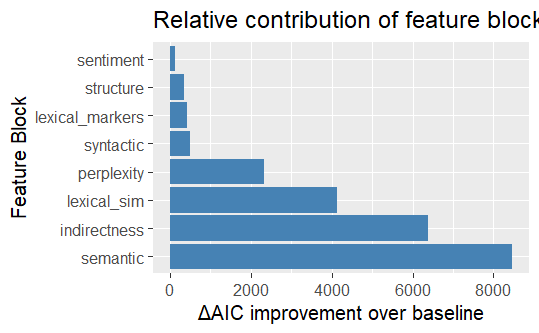

```r
library(ggplot2)
ggplot(block_results$summary[-1,], aes(x = reorder(block, -delta_AIC), y = delta_AIC)) +
  geom_col(fill = "steelblue") +
  coord_flip() +
  labs(x = "Feature Block", y = "ΔAIC improvement over baseline",
       title = "Relative contribution of feature blocks")
```

Based on the results from the blockwise fitting, the significant features for each block are identified.

```r
extract_block_details <- function(block_results) {
  library(broom.mixed)
  lapply(names(block_results$models), function(b) {
    m <- block_results$models[[b]]
    if (is.null(m)) return(NULL)
    broom.mixed::tidy(m, effects = "fixed", conf.int = TRUE, exponentiate = TRUE) %>%
      mutate(block = b)
  }) %>% bind_rows() %>% filter(term != "(Intercept)")
}
```

```r
block_details <- extract_block_details(block_results)
```

```r
strong_blocks <- c("semantic", "indirectness", "lexical_sim", "perplexity")

sig_features <- block_details %>%
  filter(block %in% strong_blocks,
         p.value < 0.05,
         abs(estimate - 1) > 0.05) %>%
  arrange(block, p.value) %>%
  select(block, term, estimate, p.value, conf.low, conf.high)

sig_features
```

| block | term | estimate | p.value | conf.low | conf.high |
| --- | --- | --- | --- | --- | --- |
| indirectness | prag_distance | 0.2937620 | 0.000000e+00 | 0.2833165 | 0.3045926 |
| indirectness | seg2_n_tokens | 0.4522137 | 6.290584e-265 | 0.4324313 | 0.4729010 |
| indirectness | seg2_impScore | 0.8189817 | 2.490499e-44 | 0.7963497 | 0.8422569 |
| indirectness | seg1_n_tokens | 1.1564491 | 3.999480e-17 | 1.1179436 | 1.1962809 |
| indirectness | seg1_impScore | 0.8938107 | 3.354133e-14 | 0.8682515 | 0.9201224 |
| lexical_sim | seg2_n_tokens | 0.4332517 | 0.000000e+00 | 0.4151774 | 0.4521130 |
| lexical_sim | tfidf_cosine_similarity | 2.1966805 | 0.000000e+00 | 2.1402899 | 2.2545569 |
| lexical_sim | seg1_n_tokens | 1.0808932 | 9.848517e-07 | 1.0477439 | 1.1150914 |
| perplexity | seg2_given_seg1_perplexity | 0.2748085 | 0.000000e+00 | 0.2600107 | 0.2904485 |
| perplexity | seg2_n_tokens | 0.4340068 | 6.232889e-301 | 0.4152739 | 0.4535847 |

[output cut: 6 more lines]

```r
cor(hard_threshold_complete[, unique(sig_features$term)], use = "pairwise.complete.obs")
```

```
                           prag_distance seg2_n_tokens seg2_impScore seg1_n_tokens seg1_impScore tfidf_cosine_similarity seg2_given_seg1_perplexity seg1_perplexity seg2_perplexity cosine_similarity
prag_distance                 1.00000000   -0.01587156    0.11274676  -0.019649794  0.0689792335           -0.4992612728                 0.25710253     0.053507542      0.04699638      -0.690404119
seg2_n_tokens                -0.01587156    1.00000000    0.20234917   0.210519086  0.0102243849           -0.0101966360                -0.30143863    -0.140306510     -0.38892087       0.022729351
seg2_impScore                 0.11274676    0.20234917    1.00000000   0.018513207  0.2754254041           -0.0740089030                 0.01893834     0.018885248     -0.08122249      -0.140591257
seg1_n_tokens                -0.01964979    0.21051909    0.01851321   1.000000000  0.2122564448            0.0392652882                -0.18800607    -0.224017381     -0.10534386       0.009993855
seg1_impScore                 0.06897923    0.01022438    0.27542540   0.212256445  1.0000000000            0.0003656658                 0.07815188    -0.009754148      0.03764944      -0.125846247
tfidf_cosine_similarity      -0.49926127   -0.01019664   -0.07400890   0.039265288  0.0003656658            1.0000000000                -0.28174502    -0.037726486     -0.03986013       0.672186907
seg2_given_seg1_perplexity    0.25710253   -0.30143863    0.01893834  -0.188006072  0.0781518765           -0.2817450215                 1.00000000     0.636244622      0.70700670      -0.350987687
seg1_perplexity               0.05350754   -0.14030651    0.01888525  -0.224017381 -0.0097541475           -0.0377264861                 0.63624462     1.000000000      0.21667552      -0.103934156
seg2_perplexity               0.04699638   -0.38892087   -0.08122249  -0.105343859  0.0376494379           -0.0398601311                 0.70700670     0.216675518      1.00000000      -0.082798369
cosine_similarity            -0.69040412    0.02272935   -0.14059126   0.009993855 -0.1258462470            0.6721869071                -0.35098769    -0.103934156     -0.08279837       1.000000000
```

# Step 2: Refine features from strong blocks

In the second step, we fit a model with all singificant features from the strong blocks identified in Step 1 and compare it to a baseline model with only the number of tokens. Then, we sequentially refine the model by adding or removing features, as well as introducing interactions between features that can interact from a theoretical perspective. The best fit is identified by improvements in AIC and R2 in comparison to the former best fit model. In addition, VIF values are checked at every step. Inside the models, ANOVA analysis is used to identify significant features and to remove features with minor or no influence on the model.

```r
final_features <- c(
  "cosine_similarity",
  "prag_distance",
  "seg2_given_seg1_perplexity",
  "seg2_n_tokens",
  "seg1_n_tokens",
  "seg1_perplexity",
  "seg2_perplexity",
  "seg1_impScore",
  "seg2_impScore",
  "tfidf_cosine_similarity"
)

f_final <- as.formula(
  paste(outcome, "~", paste(final_features, collapse = " + "), "+ (1 | CorpusID)")
)

model_baseline_entailment <-glmer(is_entailment ~ (1|CorpusID) + seg1_n_tokens + seg2_n_tokens, data = hard_threshold_complete,
                       family = binomial,
                       control = glmerControl(optimizer = "bobyqa"))

model_blocks_entailment <- glmer(f_final, data = hard_threshold_complete,
                     family = binomial,
                     control = glmerControl(optimizer = "bobyqa"))
```

```r
model_without_length_entailment <- glmer(is_entailment ~ (1|CorpusID)
                        + cosine_similarity
                        + prag_distance
                        + seg2_given_seg1_perplexity
                        + seg1_perplexity
                        + seg2_perplexity
                        #+ seg2_n_tokens
                        #+ seg1_n_tokens
                        + seg1_impScore
                        + seg2_impScore
                        + tfidf_cosine_similarity,
                        data = hard_threshold_complete, family = binomial, control = glmerControl(optimizer = "bobyqa"))
```

```r
library(car)

anova(model_baseline_entailment, model_blocks_entailment, model_without_length_entailment, test = "Chisq")
```

```
Data: hard_threshold_complete
Models:
model_baseline_entailment: is_entailment ~ (1 | CorpusID) + seg1_n_tokens + seg2_n_tokens
model_without_length_entailment: is_entailment ~ (1 | CorpusID) + cosine_similarity + prag_distance + seg2_given_seg1_perplexity + seg1_perplexity + seg2_perplexity + seg1_impScore + seg2_impScore + tfidf_cosine_similarity
model_blocks_entailment: is_entailment ~ cosine_similarity + prag_distance + seg2_given_seg1_perplexity + seg2_n_tokens + seg1_n_tokens + seg1_perplexity + seg2_perplexity + seg1_impScore + seg2_impScore + tfidf_cosine_similarity + (1 | CorpusID)
                                npar   AIC   BIC logLik -2*log(L)  Chisq Df Pr(>Chisq)
model_baseline_entailment          4 44025 44060 -22009     44017
model_without_length_entailment   10 36313 36400 -18147     36293 7723.9  6  < 2.2e-16 ***
model_blocks_entailment           12 34927 35031 -17451     34903 1390.4  2  < 2.2e-16 ***
---
Signif. codes:  0 ‘***’ 0.001 ‘**’ 0.01 ‘*’ 0.05 ‘.’ 0.1 ‘ ’ 1
```

```r
print("R2 baseline")
```

```
[1] "R2 baseline"
```

```r
performance::r2_nakagawa(model_baseline_entailment)
```

```
# R2 for Mixed Models

  Conditional R2: 0.371
     Marginal R2: 0.124
```

```r
print("R2 all block features")
```

```
[1] "R2 all block features"
```

```r
performance::r2_nakagawa(model_blocks_entailment)
```

```
# R2 for Mixed Models

  Conditional R2: 0.546
     Marginal R2: 0.395
```

```r
print("R2 without length")
```

```
[1] "R2 without length"
```

```r
performance::r2_nakagawa(model_without_length_entailment)
```

```
# R2 for Mixed Models

  Conditional R2: 0.517
     Marginal R2: 0.341
```

```r
vif(model_baseline_entailment)
```

```
seg1_n_tokens seg2_n_tokens
     1.026287      1.026287
```

```r
vif(model_blocks_entailment)
```

```
         cosine_similarity              prag_distance seg2_given_seg1_perplexity              seg2_n_tokens              seg1_n_tokens            seg1_perplexity            seg2_perplexity              seg1_impScore              seg2_impScore
                  2.272477                   1.613017                   4.594509                   1.233239                   1.127933                   2.437929                   2.678367                   1.153432                   1.175142
   tfidf_cosine_similarity
                  1.787391
```

```r
vif(model_without_length_entailment)
```

```
         cosine_similarity              prag_distance seg2_given_seg1_perplexity            seg1_perplexity            seg2_perplexity              seg1_impScore              seg2_impScore    tfidf_cosine_similarity
                  2.221561                   1.595291                   4.416582                   2.248331                   2.540120                   1.124547                   1.113781                   1.755879
```

```r
#vif(model_interact_with_length)
```

In this step, the Model with all significant features from all blocks is the best model with and R2 conditional = 0.55 and marginal = 0.4.

## Interaction perplexity features

```r
model_interact_perplexity_entailment <-  glmer(is_entailment ~ (1|CorpusID)
                        + cosine_similarity
                        + prag_distance
                        + seg2_given_seg1_perplexity
                        * seg1_perplexity
                        + seg2_given_seg1_perplexity
                        * seg2_perplexity
                        + seg2_n_tokens
                        + seg1_n_tokens
                        + seg1_impScore
                        + seg2_impScore
                        + tfidf_cosine_similarity,
                        data = hard_threshold_complete, family = binomial, control = glmerControl(optimizer = "bobyqa"))
```

```r
library(car)

anova(model_blocks_entailment, model_interact_perplexity_entailment, test = "Chisq")
```

```
Data: hard_threshold_complete
Models:
model_blocks_entailment: is_entailment ~ cosine_similarity + prag_distance + seg2_given_seg1_perplexity + seg2_n_tokens + seg1_n_tokens + seg1_perplexity + seg2_perplexity + seg1_impScore + seg2_impScore + tfidf_cosine_similarity + (1 | CorpusID)
model_interact_perplexity_entailment: is_entailment ~ (1 | CorpusID) + cosine_similarity + prag_distance + seg2_given_seg1_perplexity * seg1_perplexity + seg2_given_seg1_perplexity * seg2_perplexity + seg2_n_tokens + seg1_n_tokens + seg1_impScore + seg2_impScore + tfidf_cosine_similarity
                                     npar   AIC   BIC logLik -2*log(L)  Chisq Df Pr(>Chisq)
model_blocks_entailment                12 34927 35031 -17451     34903
model_interact_perplexity_entailment   14 34879 35002 -17426     34851 51.276  2  7.337e-12 ***
---
Signif. codes:  0 ‘***’ 0.001 ‘**’ 0.01 ‘*’ 0.05 ‘.’ 0.1 ‘ ’ 1
```

```r
print("R2 all block features")
```

```
[1] "R2 all block features"
```

```r
performance::r2_nakagawa(model_blocks_entailment)
```

```
# R2 for Mixed Models

  Conditional R2: 0.546
     Marginal R2: 0.395
```

```r
print("R2 with perplexity interactions")
```

```
[1] "R2 with perplexity interactions"
```

```r
performance::r2_nakagawa(model_interact_perplexity_entailment)
```

```
# R2 for Mixed Models

  Conditional R2: 0.548
     Marginal R2: 0.398
```

```r
vif(model_blocks_entailment)
```

```
         cosine_similarity              prag_distance seg2_given_seg1_perplexity              seg2_n_tokens              seg1_n_tokens            seg1_perplexity            seg2_perplexity              seg1_impScore              seg2_impScore
                  2.272477                   1.613017                   4.594509                   1.233239                   1.127933                   2.437929                   2.678367                   1.153432                   1.175142
   tfidf_cosine_similarity
                  1.787391
```

```r
vif(model_interact_perplexity_entailment)
```

```
                         cosine_similarity                              prag_distance                 seg2_given_seg1_perplexity                            seg1_perplexity                            seg2_perplexity
                                  2.276772                                   1.615097                                   4.538560                                   2.343911                                   2.761940
                             seg2_n_tokens                              seg1_n_tokens                              seg1_impScore                              seg2_impScore                    tfidf_cosine_similarity
                                  1.250681                                   1.131183                                   1.163873                                   1.182627                                   1.803944
seg2_given_seg1_perplexity:seg1_perplexity seg2_given_seg1_perplexity:seg2_perplexity
                                  1.281730                                   1.337784
```

```r
#vif(model_interact_with_length)
```

The interaction between perplexity features gives a significant gain in performance Conditional R2: 0.548; Marginal R2: 0.398.

## Interaction between cosine similarity and tfidf cosine similarity

```r
model_interact_tfidf_entailment <- glmer(is_entailment ~ (1|CorpusID)
                        + cosine_similarity * tfidf_cosine_similarity
                        + prag_distance
                        + seg2_given_seg1_perplexity * seg1_perplexity
                        + seg2_given_seg1_perplexity * seg2_perplexity
                        + seg2_n_tokens
                        + seg1_n_tokens
                        + seg1_impScore
                        + seg2_impScore
                        #+ tfidf_cosine_similarity
                        , data = hard_threshold_complete, family = binomial, control = glmerControl(optimizer = "bobyqa"))
```

```r
library(car)

anova(model_interact_perplexity_entailment, model_interact_tfidf_entailment, test = "Chisq")
```

```
Data: hard_threshold_complete
Models:
model_interact_perplexity_entailment: is_entailment ~ (1 | CorpusID) + cosine_similarity + prag_distance + seg2_given_seg1_perplexity * seg1_perplexity + seg2_given_seg1_perplexity * seg2_perplexity + seg2_n_tokens + seg1_n_tokens + seg1_impScore + seg2_impScore + tfidf_cosine_similarity
model_interact_tfidf_entailment: is_entailment ~ (1 | CorpusID) + cosine_similarity * tfidf_cosine_similarity + prag_distance + seg2_given_seg1_perplexity * seg1_perplexity + seg2_given_seg1_perplexity * seg2_perplexity + seg2_n_tokens + seg1_n_tokens + seg1_impScore + seg2_impScore
                                     npar   AIC   BIC logLik -2*log(L) Chisq Df Pr(>Chisq)
model_interact_perplexity_entailment   14 34879 35002 -17426     34851
model_interact_tfidf_entailment        15 34711 34842 -17341     34681 170.2  1  < 2.2e-16 ***
---
Signif. codes:  0 ‘***’ 0.001 ‘**’ 0.01 ‘*’ 0.05 ‘.’ 0.1 ‘ ’ 1
```

```r
print("R2 with perplexity interactions")
```

```
[1] "R2 with perplexity interactions"
```

```r
performance::r2_nakagawa(model_interact_perplexity_entailment)
```

```
# R2 for Mixed Models

  Conditional R2: 0.548
     Marginal R2: 0.398
```

```r
print("R2 add tfidf interaction")
```

```
[1] "R2 add tfidf interaction"
```

```r
performance::r2_nakagawa(model_interact_tfidf_entailment)
```

```
# R2 for Mixed Models

  Conditional R2: 0.563
     Marginal R2: 0.415
```

```r
vif(model_interact_perplexity_entailment)
```

```
                         cosine_similarity                              prag_distance                 seg2_given_seg1_perplexity                            seg1_perplexity                            seg2_perplexity
                                  2.276772                                   1.615097                                   4.538560                                   2.343911                                   2.761940
                             seg2_n_tokens                              seg1_n_tokens                              seg1_impScore                              seg2_impScore                    tfidf_cosine_similarity
                                  1.250681                                   1.131183                                   1.163873                                   1.182627                                   1.803944
seg2_given_seg1_perplexity:seg1_perplexity seg2_given_seg1_perplexity:seg2_perplexity
                                  1.281730                                   1.337784
```

```r
vif(model_interact_tfidf_entailment)
```

```
                         cosine_similarity                    tfidf_cosine_similarity                              prag_distance                 seg2_given_seg1_perplexity                            seg1_perplexity
                                  2.286969                                   3.756197                                   1.638297                                   4.663789                                   2.373908
                           seg2_perplexity                              seg2_n_tokens                              seg1_n_tokens                              seg1_impScore                              seg2_impScore
                                  2.786908                                   1.252403                                   1.134080                                   1.169230                                   1.187425
 cosine_similarity:tfidf_cosine_similarity seg2_given_seg1_perplexity:seg1_perplexity seg2_given_seg1_perplexity:seg2_perplexity
                                  3.053908                                   1.301611                                   1.353066
```

```r
#vif(model_interact_with_length)
```

## Interaction between cosine similarity and pragmatic distance

```r
model_interact_prag_entailment <- glmer(is_entailment ~ (1|CorpusID)
                        + cosine_similarity * tfidf_cosine_similarity
                        + cosine_similarity * prag_distance
                        #+ prag_distance
                        + seg2_given_seg1_perplexity * seg1_perplexity
                        + seg2_given_seg1_perplexity * seg2_perplexity
                        + seg2_n_tokens
                        + seg1_n_tokens
                        + seg1_impScore
                        + seg2_impScore
                        #+ tfidf_cosine_similarity
                        , data = hard_threshold_complete, family = binomial, control = glmerControl(optimizer = "bobyqa"))
```

```r
library(car)

anova(model_interact_tfidf_entailment, model_interact_prag_entailment, test = "Chisq")
```

```
Data: hard_threshold_complete
Models:
model_interact_tfidf_entailment: is_entailment ~ (1 | CorpusID) + cosine_similarity * tfidf_cosine_similarity + prag_distance + seg2_given_seg1_perplexity * seg1_perplexity + seg2_given_seg1_perplexity * seg2_perplexity + seg2_n_tokens + seg1_n_tokens + seg1_impScore + seg2_impScore
model_interact_prag_entailment: is_entailment ~ (1 | CorpusID) + cosine_similarity * tfidf_cosine_similarity + cosine_similarity * prag_distance + seg2_given_seg1_perplexity * seg1_perplexity + seg2_given_seg1_perplexity * seg2_perplexity + seg2_n_tokens + seg1_n_tokens + seg1_impScore + seg2_impSco…
                                npar   AIC   BIC logLik -2*log(L)  Chisq Df Pr(>Chisq)
model_interact_tfidf_entailment   15 34711 34842 -17341     34681
model_interact_prag_entailment    16 34713 34852 -17340     34681 0.4213  1     0.5163
```

```r
print("R2 add tfidf interaction")
```

```
[1] "R2 add tfidf interaction"
```

```r
performance::r2_nakagawa(model_interact_tfidf_entailment)
```

```
# R2 for Mixed Models

  Conditional R2: 0.563
     Marginal R2: 0.415
```

```r
print("R2 with pragmatic distance interaction")
```

```
[1] "R2 with pragmatic distance interaction"
```

```r
performance::r2_nakagawa(model_interact_prag_entailment)
```

```
# R2 for Mixed Models

  Conditional R2: 0.562
     Marginal R2: 0.413
```

```r
vif(model_interact_tfidf_entailment)
```

```
                         cosine_similarity                    tfidf_cosine_similarity                              prag_distance                 seg2_given_seg1_perplexity                            seg1_perplexity
                                  2.286969                                   3.756197                                   1.638297                                   4.663789                                   2.373908
                           seg2_perplexity                              seg2_n_tokens                              seg1_n_tokens                              seg1_impScore                              seg2_impScore
                                  2.786908                                   1.252403                                   1.134080                                   1.169230                                   1.187425
 cosine_similarity:tfidf_cosine_similarity seg2_given_seg1_perplexity:seg1_perplexity seg2_given_seg1_perplexity:seg2_perplexity
                                  3.053908                                   1.301611                                   1.353066
```

```r
vif(model_interact_prag_entailment)
```

```
                         cosine_similarity                    tfidf_cosine_similarity                              prag_distance                 seg2_given_seg1_perplexity                            seg1_perplexity
                                  2.492975                                   4.039177                                   1.829903                                   4.661904                                   2.374408
                           seg2_perplexity                              seg2_n_tokens                              seg1_n_tokens                              seg1_impScore                              seg2_impScore
                                  2.786393                                   1.252312                                   1.133868                                   1.169091                                   1.187818
 cosine_similarity:tfidf_cosine_similarity            cosine_similarity:prag_distance seg2_given_seg1_perplexity:seg1_perplexity seg2_given_seg1_perplexity:seg2_perplexity
                                  4.658481                                   2.884347                                   1.301487                                   1.353217
```

```r
#vif(model_interact_with_length)
```

## Intearction conditional perplexity and pragmatic distance

We don’t keep the cosine x prag_distance interaction

```r
model_interact_prag_per_entailment <- glmer(is_entailment ~ (1|CorpusID)
                        + cosine_similarity * tfidf_cosine_similarity
                        + cosine_similarity
                        + prag_distance * seg2_given_seg1_perplexity
                        + seg2_given_seg1_perplexity
                        * seg1_perplexity
                        + seg2_given_seg1_perplexity
                        * seg2_perplexity
                        + seg2_n_tokens
                        + seg1_n_tokens
                        + seg1_impScore
                        + seg2_impScore
                        #+ tfidf_cosine_similarity
                        , data = hard_threshold_complete, family = binomial, control = glmerControl(optimizer = "bobyqa"))
```

```r
library(car)

anova(model_interact_tfidf_entailment, model_interact_prag_per_entailment, test = "Chisq")
```

```
Data: hard_threshold_complete
Models:
model_interact_tfidf_entailment: is_entailment ~ (1 | CorpusID) + cosine_similarity * tfidf_cosine_similarity + prag_distance + seg2_given_seg1_perplexity * seg1_perplexity + seg2_given_seg1_perplexity * seg2_perplexity + seg2_n_tokens + seg1_n_tokens + seg1_impScore + seg2_impScore
model_interact_prag_per_entailment: is_entailment ~ (1 | CorpusID) + cosine_similarity * tfidf_cosine_similarity + cosine_similarity + prag_distance * seg2_given_seg1_perplexity + seg2_given_seg1_perplexity * seg1_perplexity + seg2_given_seg1_perplexity * seg2_perplexity + seg2_n_tokens + seg1_n_tok…
                                   npar   AIC   BIC logLik -2*log(L)  Chisq Df Pr(>Chisq)
model_interact_tfidf_entailment      15 34711 34842 -17341     34681
model_interact_prag_per_entailment   16 34712 34852 -17340     34680 1.0276  1     0.3107
```

```r
print("R2 add tfidf interaction")
```

```
[1] "R2 add tfidf interaction"
```

```r
performance::r2_nakagawa(model_interact_tfidf_entailment)
```

```
# R2 for Mixed Models

  Conditional R2: 0.563
     Marginal R2: 0.415
```

```r
print("R2 with pragmatic x perplexity distance interaction")
```

```
[1] "R2 with pragmatic x perplexity distance interaction"
```

```r
performance::r2_nakagawa(model_interact_prag_per_entailment)
```

```
# R2 for Mixed Models

  Conditional R2: 0.564
     Marginal R2: 0.416
```

```r
vif(model_interact_tfidf_entailment)
```

```
                         cosine_similarity                    tfidf_cosine_similarity                              prag_distance                 seg2_given_seg1_perplexity                            seg1_perplexity
                                  2.286969                                   3.756197                                   1.638297                                   4.663789                                   2.373908
                           seg2_perplexity                              seg2_n_tokens                              seg1_n_tokens                              seg1_impScore                              seg2_impScore
                                  2.786908                                   1.252403                                   1.134080                                   1.169230                                   1.187425
 cosine_similarity:tfidf_cosine_similarity seg2_given_seg1_perplexity:seg1_perplexity seg2_given_seg1_perplexity:seg2_perplexity
                                  3.053908                                   1.301611                                   1.353066
```

```r
vif(model_interact_prag_per_entailment)
```

```
                         cosine_similarity                    tfidf_cosine_similarity                              prag_distance                 seg2_given_seg1_perplexity                            seg1_perplexity
                                  2.288479                                   3.781365                                   1.661134                                   4.857952                                   2.388562
                           seg2_perplexity                              seg2_n_tokens                              seg1_n_tokens                              seg1_impScore                              seg2_impScore
                                  2.790652                                   1.253907                                   1.134777                                   1.169382                                   1.187940
 cosine_similarity:tfidf_cosine_similarity   prag_distance:seg2_given_seg1_perplexity seg2_given_seg1_perplexity:seg1_perplexity seg2_given_seg1_perplexity:seg2_perplexity
                                  3.243319                                   1.525270                                   1.304033                                   1.357863
```

```r
#vif(model_interact_with_length)
```

## Interaction cosine similarity and perplexity

```r
model_interact_sem_per_entailment <- glmer(is_entailment ~ (1|CorpusID)
                        + cosine_similarity * tfidf_cosine_similarity
                        + cosine_similarity * seg2_given_seg1_perplexity
                        + prag_distance
                        + seg2_given_seg1_perplexity
                        * seg1_perplexity
                        + seg2_given_seg1_perplexity
                        * seg2_perplexity
                        + seg2_n_tokens
                        + seg1_n_tokens
                        + seg1_impScore
                        + seg2_impScore
                        #+ tfidf_cosine_similarity
                        , data = hard_threshold_complete, family = binomial, control = glmerControl(optimizer = "bobyqa"))
```

```r
library(car)

anova(model_interact_tfidf_entailment, model_interact_sem_per_entailment, test = "Chisq")
```

```
Data: hard_threshold_complete
Models:
model_interact_tfidf_entailment: is_entailment ~ (1 | CorpusID) + cosine_similarity * tfidf_cosine_similarity + prag_distance + seg2_given_seg1_perplexity * seg1_perplexity + seg2_given_seg1_perplexity * seg2_perplexity + seg2_n_tokens + seg1_n_tokens + seg1_impScore + seg2_impScore
model_interact_sem_per_entailment: is_entailment ~ (1 | CorpusID) + cosine_similarity * tfidf_cosine_similarity + cosine_similarity * seg2_given_seg1_perplexity + prag_distance + seg2_given_seg1_perplexity * seg1_perplexity + seg2_given_seg1_perplexity * seg2_perplexity + seg2_n_tokens + seg1_n_toke…
                                  npar   AIC   BIC logLik -2*log(L)  Chisq Df Pr(>Chisq)
model_interact_tfidf_entailment     15 34711 34842 -17341     34681
model_interact_sem_per_entailment   16 34711 34850 -17339     34679 2.5776  1     0.1084
```

```r
print("R2 add tfidf interaction")
```

```
[1] "R2 add tfidf interaction"
```

```r
performance::r2_nakagawa(model_interact_tfidf_entailment)
```

```
# R2 for Mixed Models

  Conditional R2: 0.563
     Marginal R2: 0.415
```

```r
print("R2 with cosine x perplexity distance interaction")
```

```
[1] "R2 with cosine x perplexity distance interaction"
```

```r
performance::r2_nakagawa(model_interact_sem_per_entailment)
```

```
# R2 for Mixed Models

  Conditional R2: 0.565
     Marginal R2: 0.416
```

```r
vif(model_interact_tfidf_entailment)
```

```
                         cosine_similarity                    tfidf_cosine_similarity                              prag_distance                 seg2_given_seg1_perplexity                            seg1_perplexity
                                  2.286969                                   3.756197                                   1.638297                                   4.663789                                   2.373908
                           seg2_perplexity                              seg2_n_tokens                              seg1_n_tokens                              seg1_impScore                              seg2_impScore
                                  2.786908                                   1.252403                                   1.134080                                   1.169230                                   1.187425
 cosine_similarity:tfidf_cosine_similarity seg2_given_seg1_perplexity:seg1_perplexity seg2_given_seg1_perplexity:seg2_perplexity
                                  3.053908                                   1.301611                                   1.353066
```

```r
vif(model_interact_sem_per_entailment)
```

```
                           cosine_similarity                      tfidf_cosine_similarity                   seg2_given_seg1_perplexity                                prag_distance                              seg1_perplexity
                                    2.284619                                     3.809440                                     4.846762                                     1.638797                                     2.401714
                             seg2_perplexity                                seg2_n_tokens                                seg1_n_tokens                                seg1_impScore                                seg2_impScore
                                    2.799624                                     1.252409                                     1.135153                                     1.169469                                     1.187947
   cosine_similarity:tfidf_cosine_similarity cosine_similarity:seg2_given_seg1_perplexity   seg2_given_seg1_perplexity:seg1_perplexity   seg2_given_seg1_perplexity:seg2_perplexity
                                    3.377612                                     1.647021                                     1.300196                                     1.357719
```

```r
#vif(model_interact_with_length)
```

## Interaction tfidf x conditional perplexity

```r
model_interact_tfidf_per_entailment <- glmer(is_entailment ~ (1|CorpusID)
                        + cosine_similarity * tfidf_cosine_similarity
                        + tfidf_cosine_similarity * seg2_given_seg1_perplexity
                        + prag_distance
                        + seg2_given_seg1_perplexity
                        * seg1_perplexity
                        + seg2_given_seg1_perplexity
                        * seg2_perplexity
                        + seg2_n_tokens
                        + seg1_n_tokens
                        + seg1_impScore
                        + seg2_impScore
                        #+ tfidf_cosine_similarity
                        , data = hard_threshold_complete, family = binomial, control = glmerControl(optimizer = "bobyqa"))
```

```r
library(car)

anova(model_interact_tfidf_entailment, model_interact_tfidf_per_entailment, test = "Chisq")
```

```
Data: hard_threshold_complete
Models:
model_interact_tfidf_entailment: is_entailment ~ (1 | CorpusID) + cosine_similarity * tfidf_cosine_similarity + prag_distance + seg2_given_seg1_perplexity * seg1_perplexity + seg2_given_seg1_perplexity * seg2_perplexity + seg2_n_tokens + seg1_n_tokens + seg1_impScore + seg2_impScore
model_interact_tfidf_per_entailment: is_entailment ~ (1 | CorpusID) + cosine_similarity * tfidf_cosine_similarity + tfidf_cosine_similarity * seg2_given_seg1_perplexity + prag_distance + seg2_given_seg1_perplexity * seg1_perplexity + seg2_given_seg1_perplexity * seg2_perplexity + seg2_n_tokens + seg…
                                    npar   AIC   BIC logLik -2*log(L)  Chisq Df Pr(>Chisq)
model_interact_tfidf_entailment       15 34711 34842 -17341     34681
model_interact_tfidf_per_entailment   16 34696 34835 -17332     34664 17.519  1  2.844e-05 ***
---
Signif. codes:  0 ‘***’ 0.001 ‘**’ 0.01 ‘*’ 0.05 ‘.’ 0.1 ‘ ’ 1
```

```r
print("R2 add tfidf interaction")
```

```
[1] "R2 add tfidf interaction"
```

```r
performance::r2_nakagawa(model_interact_tfidf_entailment)
```

```
# R2 for Mixed Models

  Conditional R2: 0.563
     Marginal R2: 0.415
```

```r
print("R2 with tfidf x perplexity distance interaction")
```

```
[1] "R2 with tfidf x perplexity distance interaction"
```

```r
performance::r2_nakagawa(model_interact_tfidf_per_entailment)
```

```
# R2 for Mixed Models

  Conditional R2: 0.563
     Marginal R2: 0.417
```

```r
vif(model_interact_tfidf_entailment)
```

```
                         cosine_similarity                    tfidf_cosine_similarity                              prag_distance                 seg2_given_seg1_perplexity                            seg1_perplexity
                                  2.286969                                   3.756197                                   1.638297                                   4.663789                                   2.373908
                           seg2_perplexity                              seg2_n_tokens                              seg1_n_tokens                              seg1_impScore                              seg2_impScore
                                  2.786908                                   1.252403                                   1.134080                                   1.169230                                   1.187425
 cosine_similarity:tfidf_cosine_similarity seg2_given_seg1_perplexity:seg1_perplexity seg2_given_seg1_perplexity:seg2_perplexity
                                  3.053908                                   1.301611                                   1.353066
```

```r
vif(model_interact_tfidf_per_entailment)
```

```
                                 cosine_similarity                            tfidf_cosine_similarity                         seg2_given_seg1_perplexity                                      prag_distance
                                          2.293887                                           3.738434                                           4.706469                                           1.635230
                                   seg1_perplexity                                    seg2_perplexity                                      seg2_n_tokens                                      seg1_n_tokens
                                          2.398146                                           2.799575                                           1.256204                                           1.134724
                                     seg1_impScore                                      seg2_impScore          cosine_similarity:tfidf_cosine_similarity tfidf_cosine_similarity:seg2_given_seg1_perplexity
                                          1.168937                                           1.187295                                           3.449904                                           1.535972
        seg2_given_seg1_perplexity:seg1_perplexity         seg2_given_seg1_perplexity:seg2_perplexity
                                          1.298534                                           1.369758
```

```r
#vif(model_interact_with_length)
```

```r
model_interact_seg1_len_per_entailment <- glmer(is_entailment ~ (1|CorpusID)
                        + cosine_similarity * tfidf_cosine_similarity
                        + tfidf_cosine_similarity * seg2_given_seg1_perplexity
                        + prag_distance
                        + seg2_given_seg1_perplexity
                        * seg1_perplexity
                        + seg2_given_seg1_perplexity
                        * seg2_perplexity
                        + seg2_n_tokens
                        + seg1_n_tokens * seg2_given_seg1_perplexity
                        + seg1_impScore
                        + seg2_impScore
                        #+ tfidf_cosine_similarity
                        , data = hard_threshold_complete, family = binomial, control = glmerControl(optimizer = "bobyqa"))
```

```r
library(car)

anova(model_interact_tfidf_per_entailment, model_interact_seg1_len_per_entailment, test = "Chisq")
```

```
Data: hard_threshold_complete
Models:
model_interact_tfidf_per_entailment: is_entailment ~ (1 | CorpusID) + cosine_similarity * tfidf_cosine_similarity + tfidf_cosine_similarity * seg2_given_seg1_perplexity + prag_distance + seg2_given_seg1_perplexity * seg1_perplexity + seg2_given_seg1_perplexity * seg2_perplexity + seg2_n_tokens + seg…
model_interact_seg1_len_per_entailment: is_entailment ~ (1 | CorpusID) + cosine_similarity * tfidf_cosine_similarity + tfidf_cosine_similarity * seg2_given_seg1_perplexity + prag_distance + seg2_given_seg1_perplexity * seg1_perplexity + seg2_given_seg1_perplexity * seg2_perplexity + seg2_n_tokens + …
                                       npar   AIC   BIC logLik -2*log(L) Chisq Df Pr(>Chisq)
model_interact_tfidf_per_entailment      16 34696 34835 -17332     34664
model_interact_seg1_len_per_entailment   17 34686 34834 -17326     34652 11.61  1  0.0006561 ***
---
Signif. codes:  0 ‘***’ 0.001 ‘**’ 0.01 ‘*’ 0.05 ‘.’ 0.1 ‘ ’ 1
```

```r
print("R2 with tfidf x perplexity distance interaction")
```

```
[1] "R2 with tfidf x perplexity distance interaction"
```

```r
performance::r2_nakagawa(model_interact_tfidf_per_entailment)
```

```
# R2 for Mixed Models

  Conditional R2: 0.563
     Marginal R2: 0.417
```

```r
print("R2 seg1_len x perplexity interaction")
```

```
[1] "R2 seg1_len x perplexity interaction"
```

```r
performance::r2_nakagawa(model_interact_seg1_len_per_entailment)
```

```
# R2 for Mixed Models

  Conditional R2: 0.562
     Marginal R2: 0.417
```

```r
vif(model_interact_tfidf_per_entailment)
```

```
                                 cosine_similarity                            tfidf_cosine_similarity                         seg2_given_seg1_perplexity                                      prag_distance
                                          2.293887                                           3.738434                                           4.706469                                           1.635230
                                   seg1_perplexity                                    seg2_perplexity                                      seg2_n_tokens                                      seg1_n_tokens
                                          2.398146                                           2.799575                                           1.256204                                           1.134724
                                     seg1_impScore                                      seg2_impScore          cosine_similarity:tfidf_cosine_similarity tfidf_cosine_similarity:seg2_given_seg1_perplexity
                                          1.168937                                           1.187295                                           3.449904                                           1.535972
        seg2_given_seg1_perplexity:seg1_perplexity         seg2_given_seg1_perplexity:seg2_perplexity
                                          1.298534                                           1.369758
```

```r
vif(model_interact_seg1_len_per_entailment)
```

```
                                 cosine_similarity                            tfidf_cosine_similarity                         seg2_given_seg1_perplexity                                      prag_distance
                                          2.295106                                           3.738071                                           4.766745                                           1.635352
                                   seg1_perplexity                                    seg2_perplexity                                      seg2_n_tokens                                      seg1_n_tokens
                                          2.403188                                           2.799413                                           1.255749                                           1.889835
                                     seg1_impScore                                      seg2_impScore          cosine_similarity:tfidf_cosine_similarity tfidf_cosine_similarity:seg2_given_seg1_perplexity
                                          1.172921                                           1.187511                                           3.450725                                           1.539234
        seg2_given_seg1_perplexity:seg1_perplexity         seg2_given_seg1_perplexity:seg2_perplexity           seg2_given_seg1_perplexity:seg1_n_tokens
                                          1.395334                                           1.388275                                           1.922570
```

```r
#vif(model_interact_with_length)
```

## Interact ImpScore x pragmatic distance

```r
model_interact_imp_entailment <- glmer(is_entailment ~ (1|CorpusID)
                        + cosine_similarity * tfidf_cosine_similarity
                        + tfidf_cosine_similarity * seg2_given_seg1_perplexity
                        + prag_distance * seg1_impScore
                        + prag_distance * seg2_impScore
                        + seg2_given_seg1_perplexity * seg1_perplexity
                        + seg2_given_seg1_perplexity * seg2_perplexity
                        + seg2_n_tokens
                        + seg1_n_tokens * seg2_given_seg1_perplexity
                        #+ seg1_impScore
                        #+ seg2_impScore
                        #+ tfidf_cosine_similarity
                        , data = hard_threshold_complete, family = binomial, control = glmerControl(optimizer = "bobyqa"))
```

```r
library(car)

anova(model_interact_seg1_len_per_entailment, model_interact_imp_entailment, test = "Chisq")
```

```
Data: hard_threshold_complete
Models:
model_interact_seg1_len_per_entailment: is_entailment ~ (1 | CorpusID) + cosine_similarity * tfidf_cosine_similarity + tfidf_cosine_similarity * seg2_given_seg1_perplexity + prag_distance + seg2_given_seg1_perplexity * seg1_perplexity + seg2_given_seg1_perplexity * seg2_perplexity + seg2_n_tokens + …
model_interact_imp_entailment: is_entailment ~ (1 | CorpusID) + cosine_similarity * tfidf_cosine_similarity + tfidf_cosine_similarity * seg2_given_seg1_perplexity + prag_distance * seg1_impScore + prag_distance * seg2_impScore + seg2_given_seg1_perplexity * seg1_perplexity + seg2_given_seg1_perplexi…
                                       npar   AIC   BIC logLik -2*log(L)  Chisq Df Pr(>Chisq)
model_interact_seg1_len_per_entailment   17 34686 34834 -17326     34652
model_interact_imp_entailment            19 34563 34728 -17262     34525 127.37  2  < 2.2e-16 ***
---
Signif. codes:  0 ‘***’ 0.001 ‘**’ 0.01 ‘*’ 0.05 ‘.’ 0.1 ‘ ’ 1
```

```r
print("R2 seg1_len x perplexity interaction")
```

```
[1] "R2 seg1_len x perplexity interaction"
```

```r
performance::r2_nakagawa(model_interact_seg1_len_per_entailment)
```

```
# R2 for Mixed Models

  Conditional R2: 0.562
     Marginal R2: 0.417
```

```r
print("R2 with imp x prag distance")
```

```
[1] "R2 with imp x prag distance"
```

```r
performance::r2_nakagawa(model_interact_imp_entailment)
```

```
# R2 for Mixed Models

  Conditional R2: 0.580
     Marginal R2: 0.439
```

```r
vif(model_interact_seg1_len_per_entailment)
```

```
                                 cosine_similarity                            tfidf_cosine_similarity                         seg2_given_seg1_perplexity                                      prag_distance
                                          2.295106                                           3.738071                                           4.766745                                           1.635352
                                   seg1_perplexity                                    seg2_perplexity                                      seg2_n_tokens                                      seg1_n_tokens
                                          2.403188                                           2.799413                                           1.255749                                           1.889835
                                     seg1_impScore                                      seg2_impScore          cosine_similarity:tfidf_cosine_similarity tfidf_cosine_similarity:seg2_given_seg1_perplexity
                                          1.172921                                           1.187511                                           3.450725                                           1.539234
        seg2_given_seg1_perplexity:seg1_perplexity         seg2_given_seg1_perplexity:seg2_perplexity           seg2_given_seg1_perplexity:seg1_n_tokens
                                          1.395334                                           1.388275                                           1.922570
```

```r
vif(model_interact_imp_entailment)
```

```
                                 cosine_similarity                            tfidf_cosine_similarity                         seg2_given_seg1_perplexity                                      prag_distance
                                          2.298377                                           3.762950                                           4.770874                                           1.788312
                                     seg1_impScore                                      seg2_impScore                                    seg1_perplexity                                    seg2_perplexity
                                          1.535939                                           1.537927                                           2.413446                                           2.786131
                                     seg2_n_tokens                                      seg1_n_tokens          cosine_similarity:tfidf_cosine_similarity tfidf_cosine_similarity:seg2_given_seg1_perplexity
                                          1.265222                                           1.897329                                           3.510533                                           1.548953
                       prag_distance:seg1_impScore                        prag_distance:seg2_impScore         seg2_given_seg1_perplexity:seg1_perplexity         seg2_given_seg1_perplexity:seg2_perplexity
                                          1.622033                                           1.692606                                           1.396845                                           1.391201
          seg2_given_seg1_perplexity:seg1_n_tokens
                                          1.930103
```

```r
#vif(model_interact_with_length)
```

## Three-way interaction cos x tfidf x per

```r
model_interact_three_way_entailment <- glmer(is_entailment ~ (1|CorpusID)
                        + cosine_similarity * tfidf_cosine_similarity * seg2_given_seg1_perplexity
                        + prag_distance * seg1_impScore
                        + prag_distance * seg2_impScore
                        + seg2_given_seg1_perplexity
                        * seg1_perplexity
                        + seg2_given_seg1_perplexity
                        * seg2_perplexity
                        + seg2_n_tokens
                        + seg1_n_tokens * seg2_given_seg1_perplexity
                        #+ seg1_impScore
                        + seg2_impScore
                        #+ tfidf_cosine_similarity
                        , data = hard_threshold_complete, family = binomial, control = glmerControl(optimizer = "bobyqa"))
```

```r
library(car)

anova(model_interact_imp_entailment, model_interact_three_way_entailment, test = "Chisq")
```

```
Data: hard_threshold_complete
Models:
model_interact_imp_entailment: is_entailment ~ (1 | CorpusID) + cosine_similarity * tfidf_cosine_similarity + tfidf_cosine_similarity * seg2_given_seg1_perplexity + prag_distance * seg1_impScore + prag_distance * seg2_impScore + seg2_given_seg1_perplexity * seg1_perplexity + seg2_given_seg1_perplexi…
model_interact_three_way_entailment: is_entailment ~ (1 | CorpusID) + cosine_similarity * tfidf_cosine_similarity * seg2_given_seg1_perplexity + prag_distance * seg1_impScore + prag_distance * seg2_impScore + seg2_given_seg1_perplexity * seg1_perplexity + seg2_given_seg1_perplexity * seg2_perplexity…
                                    npar   AIC   BIC logLik -2*log(L)  Chisq Df Pr(>Chisq)
model_interact_imp_entailment         19 34563 34728 -17262     34525
model_interact_three_way_entailment   21 34517 34701 -17238     34475 49.253  2  2.018e-11 ***
---
Signif. codes:  0 ‘***’ 0.001 ‘**’ 0.01 ‘*’ 0.05 ‘.’ 0.1 ‘ ’ 1
```

```r
print("R2 with imp x prag distance")
```

```
[1] "R2 with imp x prag distance"
```

```r
performance::r2_nakagawa(model_interact_imp_entailment)
```

```
# R2 for Mixed Models

  Conditional R2: 0.580
     Marginal R2: 0.439
```

```r
print("R2 3-way cos x tfidf x per interaction")
```

```
[1] "R2 3-way cos x tfidf x per interaction"
```

```r
performance::r2_nakagawa(model_interact_three_way_entailment)
```

```
# R2 for Mixed Models

  Conditional R2: 0.590
     Marginal R2: 0.454
```

```r
vif(model_interact_imp_entailment)
```

```
                                 cosine_similarity                            tfidf_cosine_similarity                         seg2_given_seg1_perplexity                                      prag_distance
                                          2.298377                                           3.762950                                           4.770874                                           1.788312
                                     seg1_impScore                                      seg2_impScore                                    seg1_perplexity                                    seg2_perplexity
                                          1.535939                                           1.537927                                           2.413446                                           2.786131
                                     seg2_n_tokens                                      seg1_n_tokens          cosine_similarity:tfidf_cosine_similarity tfidf_cosine_similarity:seg2_given_seg1_perplexity
                                          1.265222                                           1.897329                                           3.510533                                           1.548953
                       prag_distance:seg1_impScore                        prag_distance:seg2_impScore         seg2_given_seg1_perplexity:seg1_perplexity         seg2_given_seg1_perplexity:seg2_perplexity
                                          1.622033                                           1.692606                                           1.396845                                           1.391201
          seg2_given_seg1_perplexity:seg1_n_tokens
                                          1.930103
```

```r
vif(model_interact_three_way_entailment)
```

```
                                                   cosine_similarity                                              tfidf_cosine_similarity                                           seg2_given_seg1_perplexity
                                                            2.292027                                                             3.875157                                                             4.959652
                                                       prag_distance                                                        seg1_impScore                                                        seg2_impScore
                                                            1.773663                                                             1.543070                                                             1.546505
                                                     seg1_perplexity                                                      seg2_perplexity                                                        seg2_n_tokens
                                                            2.424012                                                             2.770406                                                             1.259393
                                                       seg1_n_tokens                            cosine_similarity:tfidf_cosine_similarity                         cosine_similarity:seg2_given_seg1_perplexity
                                                            1.921198                                                             3.655850                                                             2.884035
                  tfidf_cosine_similarity:seg2_given_seg1_perplexity                                          prag_distance:seg1_impScore                                          prag_distance:seg2_impScore
                                                            5.967024                                                             1.626761                                                             1.697005
                          seg2_given_seg1_perplexity:seg1_perplexity                           seg2_given_seg1_perplexity:seg2_perplexity                             seg2_given_seg1_perplexity:seg1_n_tokens
                                                            1.379292                                                             1.359580                                                             1.961284
cosine_similarity:tfidf_cosine_similarity:seg2_given_seg1_perplexity
                                                            5.129664
```

```r
#vif(model_interact_with_length)
```

## Interact 3-way tfidf x prag x per

```r
model_interact_three_way_prag_entailment <- glmer(is_entailment ~ (1|CorpusID)
                        + cosine_similarity * tfidf_cosine_similarity * seg2_given_seg1_perplexity
                        + tfidf_cosine_similarity * seg2_given_seg1_perplexity * prag_distance
                        + prag_distance * seg1_impScore
                        + prag_distance * seg2_impScore
                        + seg2_given_seg1_perplexity
                        * seg1_perplexity
                        + seg2_given_seg1_perplexity
                        * seg2_perplexity
                        + seg2_n_tokens
                        + seg1_n_tokens * seg2_given_seg1_perplexity
                        #+ seg1_impScore
                        #+ seg2_impScore
                        #+ tfidf_cosine_similarity
                        , data = hard_threshold_complete, family = binomial, control = glmerControl(optimizer = "bobyqa"))
```

```r
library(car)

anova(model_interact_three_way_entailment, model_interact_three_way_prag_entailment, test = "Chisq")
```

```
Data: hard_threshold_complete
Models:
model_interact_three_way_entailment: is_entailment ~ (1 | CorpusID) + cosine_similarity * tfidf_cosine_similarity * seg2_given_seg1_perplexity + prag_distance * seg1_impScore + prag_distance * seg2_impScore + seg2_given_seg1_perplexity * seg1_perplexity + seg2_given_seg1_perplexity * seg2_perplexity…
model_interact_three_way_prag_entailment: is_entailment ~ (1 | CorpusID) + cosine_similarity * tfidf_cosine_similarity * seg2_given_seg1_perplexity + tfidf_cosine_similarity * seg2_given_seg1_perplexity * prag_distance + prag_distance * seg1_impScore + prag_distance * seg2_impScore + seg2_given_seg1…
                                         npar   AIC   BIC logLik -2*log(L)  Chisq Df Pr(>Chisq)
model_interact_three_way_entailment        21 34517 34701 -17238     34475
model_interact_three_way_prag_entailment   24 34516 34726 -17234     34468 7.0537  3    0.07021 .
---
Signif. codes:  0 ‘***’ 0.001 ‘**’ 0.01 ‘*’ 0.05 ‘.’ 0.1 ‘ ’ 1
```

```r
print("R2 3-way cos x tfidf x per interaction")
```

```
[1] "R2 3-way cos x tfidf x per interaction"
```

```r
performance::r2_nakagawa(model_interact_three_way_entailment)
```

```
# R2 for Mixed Models

  Conditional R2: 0.590
     Marginal R2: 0.454
```

```r
print("R2 3-way tfidf x per x prag")
```

```
[1] "R2 3-way tfidf x per x prag"
```

```r
performance::r2_nakagawa(model_interact_three_way_prag_entailment)
```

```
# R2 for Mixed Models

  Conditional R2: 0.591
     Marginal R2: 0.454
```

```r
vif(model_interact_three_way_entailment)
```

```
                                                   cosine_similarity                                              tfidf_cosine_similarity                                           seg2_given_seg1_perplexity
                                                            2.292027                                                             3.875157                                                             4.959652
                                                       prag_distance                                                        seg1_impScore                                                        seg2_impScore
                                                            1.773663                                                             1.543070                                                             1.546505
                                                     seg1_perplexity                                                      seg2_perplexity                                                        seg2_n_tokens
                                                            2.424012                                                             2.770406                                                             1.259393
                                                       seg1_n_tokens                            cosine_similarity:tfidf_cosine_similarity                         cosine_similarity:seg2_given_seg1_perplexity
                                                            1.921198                                                             3.655850                                                             2.884035
                  tfidf_cosine_similarity:seg2_given_seg1_perplexity                                          prag_distance:seg1_impScore                                          prag_distance:seg2_impScore
                                                            5.967024                                                             1.626761                                                             1.697005
                          seg2_given_seg1_perplexity:seg1_perplexity                           seg2_given_seg1_perplexity:seg2_perplexity                             seg2_given_seg1_perplexity:seg1_n_tokens
                                                            1.379292                                                             1.359580                                                             1.961284
cosine_similarity:tfidf_cosine_similarity:seg2_given_seg1_perplexity
                                                            5.129664
```

```r
vif(model_interact_three_way_prag_entailment)
```

```
                                                   cosine_similarity                                              tfidf_cosine_similarity                                           seg2_given_seg1_perplexity
                                                            2.310206                                                             3.863195                                                             5.021357
                                                       prag_distance                                                        seg1_impScore                                                        seg2_impScore
                                                            1.871996                                                             1.538909                                                             1.545198
                                                     seg1_perplexity                                                      seg2_perplexity                                                        seg2_n_tokens
                                                            2.428453                                                             2.772597                                                             1.259979
                                                       seg1_n_tokens                            cosine_similarity:tfidf_cosine_similarity                         cosine_similarity:seg2_given_seg1_perplexity
                                                            1.928844                                                             7.976255                                                             3.781049
                  tfidf_cosine_similarity:seg2_given_seg1_perplexity                                tfidf_cosine_similarity:prag_distance                             seg2_given_seg1_perplexity:prag_distance
                                                            5.981093                                                             6.320775                                                             2.705173
                                         prag_distance:seg1_impScore                                          prag_distance:seg2_impScore                           seg2_given_seg1_perplexity:seg1_perplexity
                                                            1.624626                                                             1.697354                                                             1.380345
                          seg2_given_seg1_perplexity:seg2_perplexity                             seg2_given_seg1_perplexity:seg1_n_tokens cosine_similarity:tfidf_cosine_similarity:seg2_given_seg1_perplexity
                                                            1.357786                                                             1.975477                                                            16.356955
    tfidf_cosine_similarity:seg2_given_seg1_perplexity:prag_distance
                                                           11.701245
```

```r
#vif(model_interact_with_length)
```

## Inspect current best fit -> three way cos x tfidf x per

We use an ANOVA to identify low-significance features

```r
Anova(model_interact_three_way_entailment)
```

```
Analysis of Deviance Table (Type II Wald chisquare tests)

Response: is_entailment
                                                                         Chisq Df Pr(>Chisq)
cosine_similarity                                                    1401.5168  1  < 2.2e-16 ***
tfidf_cosine_similarity                                                 1.1121  1  0.2916249
seg2_given_seg1_perplexity                                             88.0527  1  < 2.2e-16 ***
prag_distance                                                         351.8508  1  < 2.2e-16 ***
seg1_impScore                                                          31.1141  1  2.433e-08 ***
seg2_impScore                                                         154.6157  1  < 2.2e-16 ***
seg1_perplexity                                                        43.0747  1  5.269e-11 ***
seg2_perplexity                                                        27.7442  1  1.385e-07 ***
seg2_n_tokens                                                        1116.6586  1  < 2.2e-16 ***
seg1_n_tokens                                                          42.6533  1  6.535e-11 ***
cosine_similarity:tfidf_cosine_similarity                             196.5449  1  < 2.2e-16 ***
cosine_similarity:seg2_given_seg1_perplexity                           33.3862  1  7.556e-09 ***
tfidf_cosine_similarity:seg2_given_seg1_perplexity                     48.5392  1  3.237e-12 ***
prag_distance:seg1_impScore                                             0.3959  1  0.5292051
prag_distance:seg2_impScore                                           104.7779  1  < 2.2e-16 ***
seg2_given_seg1_perplexity:seg1_perplexity                             26.3269  1  2.883e-07 ***
seg2_given_seg1_perplexity:seg2_perplexity                              7.0915  1  0.0077450 **
seg2_given_seg1_perplexity:seg1_n_tokens                               17.4215  1  2.994e-05 ***
cosine_similarity:tfidf_cosine_similarity:seg2_given_seg1_perplexity   13.5800  1  0.0002286 ***
---
Signif. codes:  0 ‘***’ 0.001 ‘**’ 0.01 ‘*’ 0.05 ‘.’ 0.1 ‘ ’ 1
```

```r
model_interact_three_way_refined_entailment <- glmer(is_entailment ~ (1|CorpusID)
                        + cosine_similarity * tfidf_cosine_similarity * seg2_given_seg1_perplexity
                        #+ prag_distance * seg1_impScore
                        + prag_distance * seg2_impScore
                        + seg2_given_seg1_perplexity
                        * seg1_perplexity
                        + seg2_given_seg1_perplexity
                        * seg2_perplexity
                        + seg2_n_tokens
                        + seg1_n_tokens * seg2_given_seg1_perplexity
                        #+ seg1_impScore
                        + seg2_impScore
                        #+ tfidf_cosine_similarity
                        , data = hard_threshold_complete, family = binomial, control = glmerControl(optimizer = "bobyqa"))
```

```r
library(car)

anova(model_interact_three_way_entailment, model_interact_three_way_refined_entailment, test = "Chisq")
```

```
Data: hard_threshold_complete
Models:
model_interact_three_way_refined_entailment: is_entailment ~ (1 | CorpusID) + cosine_similarity * tfidf_cosine_similarity * seg2_given_seg1_perplexity + prag_distance * seg2_impScore + seg2_given_seg1_perplexity * seg1_perplexity + seg2_given_seg1_perplexity * seg2_perplexity + seg2_n_tokens + seg1_…
model_interact_three_way_entailment: is_entailment ~ (1 | CorpusID) + cosine_similarity * tfidf_cosine_similarity * seg2_given_seg1_perplexity + prag_distance * seg1_impScore + prag_distance * seg2_impScore + seg2_given_seg1_perplexity * seg1_perplexity + seg2_given_seg1_perplexity * seg2_perplexity…
                                            npar   AIC   BIC logLik -2*log(L)  Chisq Df Pr(>Chisq)
model_interact_three_way_refined_entailment   19 34545 34711 -17254     34507
model_interact_three_way_entailment           21 34517 34701 -17238     34475 31.564  2    1.4e-07 ***
---
Signif. codes:  0 ‘***’ 0.001 ‘**’ 0.01 ‘*’ 0.05 ‘.’ 0.1 ‘ ’ 1
```

```r
print("R2 3-way cos x tfidf x per interaction")
```

```
[1] "R2 3-way cos x tfidf x per interaction"
```

```r
performance::r2_nakagawa(model_interact_three_way_entailment)
```

```
# R2 for Mixed Models

  Conditional R2: 0.590
     Marginal R2: 0.454
```

```r
print("R2 3-way cos x tfidf x per interaction refined")
```

```
[1] "R2 3-way cos x tfidf x per interaction refined"
```

```r
performance::r2_nakagawa(model_interact_three_way_refined_entailment)
```

```
# R2 for Mixed Models

  Conditional R2: 0.589
     Marginal R2: 0.451
```

```r
vif(model_interact_three_way_entailment)
```

```
                                                   cosine_similarity                                              tfidf_cosine_similarity                                           seg2_given_seg1_perplexity
                                                            2.292027                                                             3.875157                                                             4.959652
                                                       prag_distance                                                        seg1_impScore                                                        seg2_impScore
                                                            1.773663                                                             1.543070                                                             1.546505
                                                     seg1_perplexity                                                      seg2_perplexity                                                        seg2_n_tokens
                                                            2.424012                                                             2.770406                                                             1.259393
                                                       seg1_n_tokens                            cosine_similarity:tfidf_cosine_similarity                         cosine_similarity:seg2_given_seg1_perplexity
                                                            1.921198                                                             3.655850                                                             2.884035
                  tfidf_cosine_similarity:seg2_given_seg1_perplexity                                          prag_distance:seg1_impScore                                          prag_distance:seg2_impScore
                                                            5.967024                                                             1.626761                                                             1.697005
                          seg2_given_seg1_perplexity:seg1_perplexity                           seg2_given_seg1_perplexity:seg2_perplexity                             seg2_given_seg1_perplexity:seg1_n_tokens
                                                            1.379292                                                             1.359580                                                             1.961284
cosine_similarity:tfidf_cosine_similarity:seg2_given_seg1_perplexity
                                                            5.129664
```

```r
vif(model_interact_three_way_refined_entailment)
```

```
                                                   cosine_similarity                                              tfidf_cosine_similarity                                           seg2_given_seg1_perplexity
                                                            2.286664                                                             3.872568                                                             4.951234
                                                       prag_distance                                                        seg2_impScore                                                      seg1_perplexity
                                                            1.762685                                                             1.460150                                                             2.410697
                                                     seg2_perplexity                                                        seg2_n_tokens                                                        seg1_n_tokens
                                                            2.766199                                                             1.258226                                                             1.899572
                           cosine_similarity:tfidf_cosine_similarity                         cosine_similarity:seg2_given_seg1_perplexity                   tfidf_cosine_similarity:seg2_given_seg1_perplexity
                                                            3.643624                                                             2.872738                                                             5.966414
                                         prag_distance:seg2_impScore                           seg2_given_seg1_perplexity:seg1_perplexity                           seg2_given_seg1_perplexity:seg2_perplexity
                                                            1.461794                                                             1.364222                                                             1.351851
                            seg2_given_seg1_perplexity:seg1_n_tokens cosine_similarity:tfidf_cosine_similarity:seg2_given_seg1_perplexity
                                                            1.981575                                                             5.131074
```

```r
#vif(model_interact_with_length)
```

```r
Anova(model_interact_three_way_refined_entailment)
```

```
Analysis of Deviance Table (Type II Wald chisquare tests)

Response: is_entailment
                                                                         Chisq Df Pr(>Chisq)
cosine_similarity                                                    1427.4413  1  < 2.2e-16 ***
tfidf_cosine_similarity                                                 1.4244  1  0.2326820
seg2_given_seg1_perplexity                                             91.1235  1  < 2.2e-16 ***
prag_distance                                                         348.8950  1  < 2.2e-16 ***
seg2_impScore                                                         199.2673  1  < 2.2e-16 ***
seg1_perplexity                                                        50.7240  1  1.063e-12 ***
seg2_perplexity                                                        27.2374  1  1.799e-07 ***
seg2_n_tokens                                                        1113.3837  1  < 2.2e-16 ***
seg1_n_tokens                                                          33.5610  1  6.906e-09 ***
cosine_similarity:tfidf_cosine_similarity                             195.1197  1  < 2.2e-16 ***
cosine_similarity:seg2_given_seg1_perplexity                           33.5945  1  6.788e-09 ***
tfidf_cosine_similarity:seg2_given_seg1_perplexity                     48.1557  1  3.937e-12 ***
prag_distance:seg2_impScore                                           113.4485  1  < 2.2e-16 ***
seg2_given_seg1_perplexity:seg1_perplexity                             32.4989  1  1.193e-08 ***
seg2_given_seg1_perplexity:seg2_perplexity                              9.3835  1  0.0021895 **
seg2_given_seg1_perplexity:seg1_n_tokens                               14.7573  1  0.0001223 ***
cosine_similarity:tfidf_cosine_similarity:seg2_given_seg1_perplexity   13.3039  1  0.0002648 ***
---
Signif. codes:  0 ‘***’ 0.001 ‘**’ 0.01 ‘*’ 0.05 ‘.’ 0.1 ‘ ’ 1
```

```r
library(broom.mixed)
library(dplyr)

effects_table <- tidy(model_interact_three_way_refined, effects = "fixed", conf.int = TRUE) %>%
  arrange(p.value) %>%
  mutate(significance = case_when(
    p.value < 0.001 ~ "***",
    p.value < 0.01  ~ "**",
    p.value < 0.05  ~ "*",
    TRUE ~ ""
  ))

effects_table
```

| effect | term | estimate | std.error | statistic | p.value | conf.low | conf.high | significance |
| --- | --- | --- | --- | --- | --- | --- | --- | --- |
| fixed | cosine_similarity | 1.01911469 | 0.02759327 | 36.933455 | 1.342684e-298 | 0.96503288 | 1.073196498 | *** |
| fixed | seg2_n_tokens | -0.85436005 | 0.02560463 | -33.367405 | 4.074087e-244 | -0.90454420 | -0.804175897 | *** |
| fixed | prag_distance | -0.50815188 | 0.02430487 | -20.907407 | 4.584782e-97 | -0.55578856 | -0.460515206 | *** |
| fixed | seg2_impScore | -0.29348218 | 0.01670745 | -17.565945 | 4.491544e-69 | -0.32622819 | -0.260736180 | *** |
| fixed | cosine_similarity:tfidf_cosine_similarity | -0.23684908 | 0.01641045 | -14.432823 | 3.216439e-47 | -0.26901297 | -0.204685194 | *** |
| fixed | prag_distance:seg2_impScore | -0.19356309 | 0.01817286 | -10.651219 | 1.720974e-26 | -0.22918123 | -0.157944938 | *** |
| fixed | seg2_given_seg1_perplexity | -0.32273907 | 0.03752080 | -8.601604 | 7.860962e-18 | -0.39627849 | -0.249199651 | *** |
| fixed | tfidf_cosine_similarity | 0.21603099 | 0.02651235 | 8.148314 | 3.690316e-16 | 0.16406773 | 0.267994242 | *** |
| fixed | seg1_perplexity | 0.16465618 | 0.02355471 | 6.990371 | 2.741607e-12 | 0.11848979 | 0.210822570 | *** |
| fixed | seg1_n_tokens | 0.16093207 | 0.02332031 | 6.900940 | 5.165960e-12 | 0.11522510 | 0.206639045 | *** |

[output cut: 8 more lines]

# Step 3: Check remaining feature blocks

```r
library(lme4)
library(performance)
library(broom.mixed)
library(purrr)

# Define your dropped blocks from earlier
blocks_dropped <- list(
  syntactic = c("seg1_dependency_distance_mean", "seg2_dependency_distance_mean",
                "seg1_prop_adjacent_dependency_relation_mean", "seg2_prop_adjacent_dependency_relation_mean",
                "seg1_avg_subclauses", "seg2_avg_subclauses",
                "seg1_avg_tree_depth", "seg2_avg_tree_depth"),
  structure = c("seg1_sentence_length_mean", "seg2_sentence_length_mean"),
  sentiment = c("seg1_senti", "seg2_senti"),
  lexical_markers = c("seg1_has_deduction", "seg2_has_deduction",
                      "seg1_has_refutation", "seg2_has_refutation",
                      "seg1_has_condition", "seg2_has_condition",
                      "seg1_has_explanation", "seg2_has_explanation",
                      "seg1_has_adverb_of_emphasis", "seg2_has_adverb_of_emphasis",
                      "seg1_has_justification", "seg2_has_justification",
                      "seg1_has_modal_verbs", "seg2_has_modal_verbs")
)

# Loop through them and test one-at-a-time addition
block_refit_results_entailment <- map_df(names(blocks_dropped), function(b) {
  predictors <- paste(blocks_dropped[[b]], collapse = " + ")
  m_block <- update(model_interact_three_way_refined, paste(". ~ . +", predictors))
  comp <- anova(model_interact_three_way_refined, m_block, test = "Chisq")
  tibble(
    block = b,
    delta_AIC = AIC(model_interact_three_way_refined) - AIC(m_block),
    LRT_p = comp$`Pr(>Chisq)`[2],
    R2_marg_gain = performance::r2_nakagawa(m_block)$R2_marginal -
                   performance::r2_nakagawa(model_interact_three_way_refined)$R2_marginal
  )
})

block_refit_results
```

[output not shown]

```r
#summary(update(model_interact_three_way_refined, . ~ . + seg1_avg_tree_depth + seg2_avg_tree_depth))
car::Anova(update(model_interact_three_way_refined_entailment, . ~ . #+ seg1_has_deduction
                                                          + seg2_has_deduction
                                                          #+ seg1_has_refutation
                                                          + seg2_has_refutation
                                                          + seg1_has_condition
                                                          #+ seg2_has_condition
                                                          #+ seg1_has_explanation
                                                          + seg2_has_explanation
                                                          #+ seg1_has_adverb_of_emphasis
                                                          + seg2_has_adverb_of_emphasis
                                                          #+ seg1_has_justification
                                                          + seg2_has_justification
                                                          + seg1_has_modal_verbs
                                                          + seg2_has_modal_verbs), type="III")
```

[output not shown]

```r
car::Anova(update(model_interact_three_way_refined, . ~ . + seg1_sentence_length_mean
                                                          + seg2_sentence_length_mean), type="III")
```

```
Analysis of Deviance Table (Type III Wald chisquare tests)

Response: is_entailment
                                                                         Chisq Df Pr(>Chisq)
(Intercept)                                                            23.5593  1  1.211e-06 ***
cosine_similarity                                                    1354.2893  1  < 2.2e-16 ***
tfidf_cosine_similarity                                                61.7283  1  3.943e-15 ***
seg2_given_seg1_perplexity                                             82.5889  1  < 2.2e-16 ***
prag_distance                                                         435.5613  1  < 2.2e-16 ***
seg2_impScore                                                         326.3543  1  < 2.2e-16 ***
seg1_perplexity                                                        85.1818  1  < 2.2e-16 ***
seg2_perplexity                                                        27.0232  1  2.010e-07 ***
seg2_n_tokens                                                         790.5621  1  < 2.2e-16 ***
seg1_n_tokens                                                           2.1233  1   0.145078
seg1_sentence_length_mean                                             190.1134  1  < 2.2e-16 ***
seg2_sentence_length_mean                                              51.2543  1  8.114e-13 ***
cosine_similarity:tfidf_cosine_similarity                             192.3506  1  < 2.2e-16 ***
cosine_similarity:seg2_given_seg1_perplexity                           26.0166  1  3.385e-07 ***
tfidf_cosine_similarity:seg2_given_seg1_perplexity                      2.7620  1   0.096528 .
prag_distance:seg2_impScore                                           112.6616  1  < 2.2e-16 ***
seg2_given_seg1_perplexity:seg1_perplexity                             41.9663  1  9.286e-11 ***
seg2_given_seg1_perplexity:seg2_perplexity                             10.5359  1   0.001171 **
seg2_given_seg1_perplexity:seg1_n_tokens                                1.9843  1   0.158939
cosine_similarity:tfidf_cosine_similarity:seg2_given_seg1_perplexity    8.6529  1   0.003265 **
---
Signif. codes:  0 ‘***’ 0.001 ‘**’ 0.01 ‘*’ 0.05 ‘.’ 0.1 ‘ ’ 1
```

```r
car::Anova(update(model_interact_three_way_refined, . ~ . + seg1_senti + seg2_senti), type="III")
```

```
Analysis of Deviance Table (Type III Wald chisquare tests)

Response: is_entailment
                                                                         Chisq Df Pr(>Chisq)
(Intercept)                                                            36.1377  1  1.839e-09 ***
cosine_similarity                                                    1398.0955  1  < 2.2e-16 ***
tfidf_cosine_similarity                                                68.4993  1  < 2.2e-16 ***
seg2_given_seg1_perplexity                                             78.4173  1  < 2.2e-16 ***
prag_distance                                                         423.7799  1  < 2.2e-16 ***
seg2_impScore                                                         348.2479  1  < 2.2e-16 ***
seg1_perplexity                                                        47.6914  1  4.989e-12 ***
seg2_perplexity                                                        25.5206  1  4.377e-07 ***
seg2_n_tokens                                                        1038.8483  1  < 2.2e-16 ***
seg1_n_tokens                                                          44.8468  1  2.131e-11 ***
seg1_senti                                                             32.4677  1  1.212e-08 ***
seg2_senti                                                            302.3886  1  < 2.2e-16 ***
cosine_similarity:tfidf_cosine_similarity                             206.0353  1  < 2.2e-16 ***
cosine_similarity:seg2_given_seg1_perplexity                           31.2771  1  2.237e-08 ***
tfidf_cosine_similarity:seg2_given_seg1_perplexity                      3.6813  1  0.0550250 .
prag_distance:seg2_impScore                                           112.2929  1  < 2.2e-16 ***
seg2_given_seg1_perplexity:seg1_perplexity                             32.2081  1  1.385e-08 ***
seg2_given_seg1_perplexity:seg2_perplexity                              9.6745  1  0.0018684 **
seg2_given_seg1_perplexity:seg1_n_tokens                               13.9257  1  0.0001902 ***
cosine_similarity:tfidf_cosine_similarity:seg2_given_seg1_perplexity   12.9703  1  0.0003165 ***
---
Signif. codes:  0 ‘***’ 0.001 ‘**’ 0.01 ‘*’ 0.05 ‘.’ 0.1 ‘ ’ 1
```

```r
car::Anova(update(model_interact_three_way_refined, . ~ . + seg1_dependency_distance_mean
                                                          + seg2_dependency_distance_mean
                                                          + seg1_prop_adjacent_dependency_relation_mean
                                                          + seg2_prop_adjacent_dependency_relation_mean
                                                          + seg1_avg_subclauses
                                                          + seg2_avg_subclauses
                                                          + seg1_avg_tree_depth
                                                          + seg2_avg_tree_depth), type="III")
```

```
Analysis of Deviance Table (Type III Wald chisquare tests)

Response: is_entailment
                                                                         Chisq Df Pr(>Chisq)
(Intercept)                                                            26.2901  1  2.938e-07 ***
cosine_similarity                                                    1319.7427  1  < 2.2e-16 ***
tfidf_cosine_similarity                                                63.4941  1  1.608e-15 ***
seg2_given_seg1_perplexity                                             94.9604  1  < 2.2e-16 ***
prag_distance                                                         438.2810  1  < 2.2e-16 ***
seg2_impScore                                                         273.8563  1  < 2.2e-16 ***
seg1_perplexity                                                        96.7950  1  < 2.2e-16 ***
seg2_perplexity                                                        23.1388  1  1.507e-06 ***
seg2_n_tokens                                                         708.6806  1  < 2.2e-16 ***
seg1_n_tokens                                                           0.4240  1  0.5149692
seg1_dependency_distance_mean                                           4.1802  1  0.0408989 *
seg2_dependency_distance_mean                                          11.8873  1  0.0005652 ***
seg1_prop_adjacent_dependency_relation_mean                             7.8034  1  0.0052149 **
seg2_prop_adjacent_dependency_relation_mean                            16.8962  1  3.948e-05 ***
seg1_avg_subclauses                                                    12.1561  1  0.0004893 ***
seg2_avg_subclauses                                                     0.0183  1  0.8923851
seg1_avg_tree_depth                                                    35.1285  1  3.087e-09 ***
seg2_avg_tree_depth                                                    32.4986  1  1.193e-08 ***
cosine_similarity:tfidf_cosine_similarity                             187.8330  1  < 2.2e-16 ***
cosine_similarity:seg2_given_seg1_perplexity                           27.0822  1  1.950e-07 ***
tfidf_cosine_similarity:seg2_given_seg1_perplexity                      3.4866  1  0.0618676 .
prag_distance:seg2_impScore                                           108.8589  1  < 2.2e-16 ***
seg2_given_seg1_perplexity:seg1_perplexity                             42.0527  1  8.884e-11 ***
seg2_given_seg1_perplexity:seg2_perplexity                             18.1177  1  2.077e-05 ***
seg2_given_seg1_perplexity:seg1_n_tokens                                1.4597  1  0.2269848
cosine_similarity:tfidf_cosine_similarity:seg2_given_seg1_perplexity    7.6756  1  0.0055973 **
---
Signif. codes:  0 ‘***’ 0.001 ‘**’ 0.01 ‘*’ 0.05 ‘.’ 0.1 ‘ ’ 1
```

## Add sinificant features from other blocks

```r
model_final_expanded_interactions_entailment <- glmer(
  is_entailment ~ (1 | CorpusID)
  + cosine_similarity * tfidf_cosine_similarity
  + seg2_given_seg1_perplexity * cosine_similarity
  + prag_distance * seg2_impScore
  + seg2_given_seg1_perplexity * seg1_perplexity
  + seg2_given_seg1_perplexity * seg2_perplexity
  + seg2_n_tokens * seg2_sentence_length_mean
  + seg2_n_tokens * seg2_avg_tree_depth
  + seg2_sentence_length_mean * seg2_avg_tree_depth
  + seg1_sentence_length_mean * seg1_avg_tree_depth
  + seg1_senti
  + seg2_senti
  + seg2_has_refutation
  + seg1_has_condition
  + seg1_has_modal_verbs
  + seg2_has_modal_verbs
  , data = hard_threshold_complete,
  family = binomial,
  control = glmerControl(optimizer = "bobyqa")
)
```

```r
anova(model_interact_three_way_refined_entailment, model_final_expanded_interactions_entailment, test = "Chisq")
```

```
Data: hard_threshold_complete
Models:
model_interact_three_way_refined_entailment: is_entailment ~ (1 | CorpusID) + cosine_similarity * tfidf_cosine_similarity * seg2_given_seg1_perplexity + prag_distance * seg2_impScore + seg2_given_seg1_perplexity * seg1_perplexity + seg2_given_seg1_perplexity * seg2_perplexity + seg2_n_tokens + seg1_…
model_final_expanded_interactions_entailment: is_entailment ~ (1 | CorpusID) + cosine_similarity * tfidf_cosine_similarity + seg2_given_seg1_perplexity * cosine_similarity + prag_distance * seg2_impScore + seg2_given_seg1_perplexity * seg1_perplexity + seg2_given_seg1_perplexity * seg2_perplexity + …
                                             npar   AIC   BIC logLik -2*log(L)  Chisq Df Pr(>Chisq)
model_interact_three_way_refined_entailment    19 34545 34711 -17254     34507
model_final_expanded_interactions_entailment   29 33546 33799 -16744     33488 1018.7 10  < 2.2e-16 ***
---
Signif. codes:  0 ‘***’ 0.001 ‘**’ 0.01 ‘*’ 0.05 ‘.’ 0.1 ‘ ’ 1
```

```r
print("R2 for model_interact_three_way_refined")
```

```
[1] "R2 for model_interact_three_way_refined"
```

```r
performance::r2_nakagawa(model_interact_three_way_refined_entailment)
```

```
# R2 for Mixed Models

  Conditional R2: 0.589
     Marginal R2: 0.451
```

```r
print("R2 for model_final_expanded_interactions")
```

```
[1] "R2 for model_final_expanded_interactions"
```

```r
performance::r2_nakagawa(model_final_expanded_interactions_entailment)
```

```
# R2 for Mixed Models

  Conditional R2: 0.605
     Marginal R2: 0.472
```

## Interaction tree depth

```r
model_final_expanded_tree_depth_entailment <- glmer(
  is_entailment ~ (1 | CorpusID)
  + cosine_similarity * tfidf_cosine_similarity
  + seg2_given_seg1_perplexity * cosine_similarity
  + prag_distance * seg2_impScore
  + seg2_given_seg1_perplexity * seg1_perplexity
  + seg2_given_seg1_perplexity * seg2_perplexity
  # + seg2_n_tokens * seg2_sentence_length_mean
  #+ seg2_n_tokens * seg2_avg_tree_depth
  #+ seg2_sentence_length_mean *
  + seg2_avg_tree_depth
  + seg1_avg_tree_depth
  #+ seg1_sentence_length_mean
  + seg1_senti
  + seg2_senti
  + seg2_has_refutation
  + seg1_has_condition
  + seg1_has_modal_verbs
  + seg2_has_modal_verbs
  , data = hard_threshold_complete,
  family = binomial,
  control = glmerControl(optimizer = "bobyqa")
)
```

```r
anova(model_final_expanded_interactions_entailment, model_final_expanded_tree_depth_entailment, test = "Chisq")
```

```
Data: hard_threshold_complete
Models:
model_final_expanded_tree_depth_entailment: is_entailment ~ (1 | CorpusID) + cosine_similarity * tfidf_cosine_similarity + seg2_given_seg1_perplexity * cosine_similarity + prag_distance * seg2_impScore + seg2_given_seg1_perplexity * seg1_perplexity + seg2_given_seg1_perplexity * seg2_perplexity + se…
model_final_expanded_interactions_entailment: is_entailment ~ (1 | CorpusID) + cosine_similarity * tfidf_cosine_similarity + seg2_given_seg1_perplexity * cosine_similarity + prag_distance * seg2_impScore + seg2_given_seg1_perplexity * seg1_perplexity + seg2_given_seg1_perplexity * seg2_perplexity + …
                                             npar   AIC   BIC logLik -2*log(L) Chisq Df Pr(>Chisq)
model_final_expanded_tree_depth_entailment     22 34756 34948 -17356     34712
model_final_expanded_interactions_entailment   29 33546 33799 -16744     33488  1224  7  < 2.2e-16 ***
---
Signif. codes:  0 ‘***’ 0.001 ‘**’ 0.01 ‘*’ 0.05 ‘.’ 0.1 ‘ ’ 1
```

```r
message("R2 for model_final_expanded_interactions")
performance::r2_nakagawa(model_final_expanded_interactions_entailment)
```

```
# R2 for Mixed Models

  Conditional R2: 0.605
     Marginal R2: 0.472
```

```r
message("R2 for model_final_expanded_tree_depth")
performance::r2_nakagawa(model_final_expanded_tree_depth_entailment)
```

```
# R2 for Mixed Models

  Conditional R2: 0.570
     Marginal R2: 0.426
```

## sentence lenght vs tokens as length measure

```r
model_final_expanded_sentence_length_entailment <- glmer(
  is_entailment ~ (1 | CorpusID)
  + cosine_similarity * tfidf_cosine_similarity
  + seg2_given_seg1_perplexity * cosine_similarity
  + prag_distance * seg2_impScore
  + seg2_given_seg1_perplexity * seg1_perplexity
  + seg2_given_seg1_perplexity * seg2_perplexity
  # + seg2_n_tokens * seg2_sentence_length_mean
  #+ seg2_n_tokens * seg2_avg_tree_depth
  + seg2_sentence_length_mean #*
  #+ seg2_avg_tree_depth
  + seg1_sentence_length_mean
  + seg1_senti
  + seg2_senti
  + seg2_has_refutation
  + seg1_has_condition
  + seg1_has_modal_verbs
  + seg2_has_modal_verbs
  , data = hard_threshold_complete,
  family = binomial,
  control = glmerControl(optimizer = "bobyqa")
)
```

```r
model_final_expanded_n_tokens_entailment <- glmer(
  is_entailment ~ (1 | CorpusID)
  + cosine_similarity * tfidf_cosine_similarity
  + seg2_given_seg1_perplexity * cosine_similarity
  + prag_distance * seg2_impScore
  + seg2_given_seg1_perplexity * seg1_perplexity
  + seg2_given_seg1_perplexity * seg2_perplexity
  + seg2_n_tokens
  #* seg2_sentence_length_mean
  #+ seg2_n_tokens * seg2_avg_tree_depth
  #+ seg2_sentence_length_mean #*
  #+ seg2_avg_tree_depth
  #+ seg1_sentence_length_mean
  + seg1_senti
  + seg2_senti
  + seg2_has_refutation
  + seg1_has_condition
  + seg1_has_modal_verbs
  + seg2_has_modal_verbs
  , data = hard_threshold_complete,
  family = binomial,
  control = glmerControl(optimizer = "bobyqa")
)
```

```r
anova(model_final_expanded_n_tokens_entailment, model_final_expanded_sentence_length_entailment, test = "Chisq")
```

```
Data: hard_threshold_complete
Models:
model_final_expanded_n_tokens_entailment: is_entailment ~ (1 | CorpusID) + cosine_similarity * tfidf_cosine_similarity + seg2_given_seg1_perplexity * cosine_similarity + prag_distance * seg2_impScore + seg2_given_seg1_perplexity * seg1_perplexity + seg2_given_seg1_perplexity * seg2_perplexity + seg2…
model_final_expanded_sentence_length_entailment: is_entailment ~ (1 | CorpusID) + cosine_similarity * tfidf_cosine_similarity + seg2_given_seg1_perplexity * cosine_similarity + prag_distance * seg2_impScore + seg2_given_seg1_perplexity * seg1_perplexity + seg2_given_seg1_perplexity * seg2_perplexity…
                                                npar   AIC   BIC logLik -2*log(L) Chisq Df Pr(>Chisq)
model_final_expanded_n_tokens_entailment          21 34002 34185 -16980     33960
model_final_expanded_sentence_length_entailment   22 34569 34761 -17262     34525     0  1          1
```

```r
message("R2 for model_final_expanded_sentence_length")
performance::r2_nakagawa(model_final_expanded_sentence_length_entailment)
```

```
# R2 for Mixed Models

  Conditional R2: 0.574
     Marginal R2: 0.435
```

```r
message("R2 for model_final_expanded_n_tokens")
performance::r2_nakagawa(model_final_expanded_n_tokens_entailment)
```

```
# R2 for Mixed Models

  Conditional R2: 0.594
     Marginal R2: 0.449
```

## 3-way interaction

```r
model_final_expanded_n_tokens_threeWay_entailment <- glmer(
  is_entailment ~ (1 | CorpusID)
  + cosine_similarity * tfidf_cosine_similarity
  * seg2_given_seg1_perplexity #* cosine_similarity
  + prag_distance * seg2_impScore
  + seg2_given_seg1_perplexity * seg1_perplexity
  + seg2_given_seg1_perplexity * seg2_perplexity
  + seg2_n_tokens #* seg2_sentence_length_mean
  #+ seg2_n_tokens * seg2_avg_tree_depth
  #+ seg2_sentence_length_mean * seg2_avg_tree_depth
  #+ seg1_sentence_length_mean * seg1_avg_tree_depth
  + seg1_senti
  + seg2_senti
  + seg2_has_refutation
  + seg1_has_condition
  + seg1_has_modal_verbs
  + seg2_has_modal_verbs
  , data = hard_threshold_complete,
  family = binomial,
  control = glmerControl(optimizer = "bobyqa")
)
```

```r
anova(model_final_expanded_n_tokens_entailment, model_final_expanded_n_tokens_threeWay_entailment, test = "Chisq")
```

```
Data: hard_threshold_complete
Models:
model_final_expanded_n_tokens_entailment: is_entailment ~ (1 | CorpusID) + cosine_similarity * tfidf_cosine_similarity + seg2_given_seg1_perplexity * cosine_similarity + prag_distance * seg2_impScore + seg2_given_seg1_perplexity * seg1_perplexity + seg2_given_seg1_perplexity * seg2_perplexity + seg2…
model_final_expanded_n_tokens_threeWay_entailment: is_entailment ~ (1 | CorpusID) + cosine_similarity * tfidf_cosine_similarity * seg2_given_seg1_perplexity + prag_distance * seg2_impScore + seg2_given_seg1_perplexity * seg1_perplexity + seg2_given_seg1_perplexity * seg2_perplexity + seg2_n_tokens +…
                                                  npar   AIC   BIC logLik -2*log(L) Chisq Df Pr(>Chisq)
model_final_expanded_n_tokens_entailment            21 34002 34185 -16980     33960
model_final_expanded_n_tokens_threeWay_entailment   23 33949 34150 -16952     33903 56.55  2  5.253e-13 ***
---
Signif. codes:  0 ‘***’ 0.001 ‘**’ 0.01 ‘*’ 0.05 ‘.’ 0.1 ‘ ’ 1
```

```r
message("R2 for model_final_expanded_n_tokens")
performance::r2_nakagawa(model_final_expanded_n_tokens_entailment)
```

```
# R2 for Mixed Models

  Conditional R2: 0.594
     Marginal R2: 0.449
```

```r
message("R2 for model_final_expanded_n_tokens_threeWay")
performance::r2_nakagawa(model_final_expanded_n_tokens_threeWay_entailment)
```

```
# R2 for Mixed Models

  Conditional R2: 0.602
     Marginal R2: 0.463
```

```r
model_final_expanded_n_tokens_noMarginal_entailment <- glmer(
  is_entailment ~ (1 | CorpusID)
  + cosine_similarity * tfidf_cosine_similarity
  #* seg2_given_seg1_perplexity #* cosine_similarity
  + prag_distance * seg2_impScore
  + seg2_given_seg1_perplexity * seg1_perplexity
  + seg2_given_seg1_perplexity * seg2_perplexity
  + seg2_n_tokens #* seg2_sentence_length_mean
  #+ seg2_n_tokens * seg2_avg_tree_depth
  #+ seg2_sentence_length_mean * seg2_avg_tree_depth
  #+ seg1_sentence_length_mean * seg1_avg_tree_depth
  + seg1_senti
  + seg2_senti
  + seg2_has_refutation
  + seg1_has_condition
  + seg1_has_modal_verbs
  + seg2_has_modal_verbs
  , data = hard_threshold_complete,
  family = binomial,
  control = glmerControl(optimizer = "bobyqa")
)
```

```r
anova(model_final_expanded_n_tokens_threeWay_entailment, model_final_expanded_n_tokens_noMarginal_entailment, test = "Chisq")
```

```
Data: hard_threshold_complete
Models:
model_final_expanded_n_tokens_noMarginal_entailment: is_entailment ~ (1 | CorpusID) + cosine_similarity * tfidf_cosine_similarity + prag_distance * seg2_impScore + seg2_given_seg1_perplexity * seg1_perplexity + seg2_given_seg1_perplexity * seg2_perplexity + seg2_n_tokens + seg1_senti + seg2_senti + …
model_final_expanded_n_tokens_threeWay_entailment: is_entailment ~ (1 | CorpusID) + cosine_similarity * tfidf_cosine_similarity * seg2_given_seg1_perplexity + prag_distance * seg2_impScore + seg2_given_seg1_perplexity * seg1_perplexity + seg2_given_seg1_perplexity * seg2_perplexity + seg2_n_tokens +…
                                                    npar   AIC   BIC logLik -2*log(L)  Chisq Df Pr(>Chisq)
model_final_expanded_n_tokens_noMarginal_entailment   20 34003 34178 -16982     33963
model_final_expanded_n_tokens_threeWay_entailment     23 33949 34150 -16952     33903 59.715  3  6.763e-13 ***
---
Signif. codes:  0 ‘***’ 0.001 ‘**’ 0.01 ‘*’ 0.05 ‘.’ 0.1 ‘ ’ 1
```

```r
message("R2 for model_final_expanded_n_tokens_threeWay")
performance::r2_nakagawa(model_final_expanded_n_tokens_threeWay_entailment)
```

```
# R2 for Mixed Models

  Conditional R2: 0.602
     Marginal R2: 0.463
```

```r
message("R2 for model_final_expanded_n_tokens_noMarginal")
performance::r2_nakagawa(model_final_expanded_n_tokens_noMarginal_entailment)
```

```
# R2 for Mixed Models

  Conditional R2: 0.593
     Marginal R2: 0.448
```

```r
car::Anova(model_final_expanded_interactions_entailment, type="III")
```

```
Analysis of Deviance Table (Type III Wald chisquare tests)

Response: is_entailment
                                                  Chisq Df Pr(>Chisq)
(Intercept)                                     33.1795  1  8.403e-09 ***
cosine_similarity                             1351.1484  1  < 2.2e-16 ***
tfidf_cosine_similarity                         76.4243  1  < 2.2e-16 ***
seg2_given_seg1_perplexity                      95.4382  1  < 2.2e-16 ***
prag_distance                                  420.0359  1  < 2.2e-16 ***
seg2_impScore                                  342.0671  1  < 2.2e-16 ***
seg1_perplexity                                105.8812  1  < 2.2e-16 ***
seg2_perplexity                                 24.8657  1  6.147e-07 ***
seg2_n_tokens                                  686.5429  1  < 2.2e-16 ***
seg2_sentence_length_mean                       14.5635  1  0.0001355 ***
seg2_avg_tree_depth                             33.5451  1  6.963e-09 ***
seg1_sentence_length_mean                      106.0553  1  < 2.2e-16 ***
seg1_avg_tree_depth                             31.9021  1  1.621e-08 ***
seg1_senti                                      23.5077  1  1.244e-06 ***
seg2_senti                                     242.4330  1  < 2.2e-16 ***
seg2_has_refutation                            223.5720  1  < 2.2e-16 ***
seg1_has_condition                              60.6876  1  6.689e-15 ***
seg1_has_modal_verbs                            20.1573  1  7.133e-06 ***
seg2_has_modal_verbs                            15.5058  1  8.225e-05 ***
cosine_similarity:tfidf_cosine_similarity      150.3398  1  < 2.2e-16 ***
cosine_similarity:seg2_given_seg1_perplexity     3.5345  1  0.0601061 .
prag_distance:seg2_impScore                    103.7539  1  < 2.2e-16 ***
seg2_given_seg1_perplexity:seg1_perplexity      52.4185  1  4.485e-13 ***
seg2_given_seg1_perplexity:seg2_perplexity      14.7972  1  0.0001197 ***
seg2_n_tokens:seg2_sentence_length_mean         18.4603  1  1.735e-05 ***
seg2_n_tokens:seg2_avg_tree_depth               28.2779  1  1.051e-07 ***
seg2_sentence_length_mean:seg2_avg_tree_depth   54.8988  1  1.269e-13 ***
seg1_sentence_length_mean:seg1_avg_tree_depth   36.3954  1  1.611e-09 ***
---
Signif. codes:  0 ‘***’ 0.001 ‘**’ 0.01 ‘*’ 0.05 ‘.’ 0.1 ‘ ’ 1
```

```r
car::Anova(model_final_expanded_n_tokens_threeWay_entailment, type="III")
```

```
Analysis of Deviance Table (Type III Wald chisquare tests)

Response: is_entailment
                                                                         Chisq Df Pr(>Chisq)
(Intercept)                                                            27.7932  1  1.350e-07 ***
cosine_similarity                                                    1357.1831  1  < 2.2e-16 ***
tfidf_cosine_similarity                                                77.4307  1  < 2.2e-16 ***
seg2_given_seg1_perplexity                                             84.9201  1  < 2.2e-16 ***
prag_distance                                                         426.5563  1  < 2.2e-16 ***
seg2_impScore                                                         350.3944  1  < 2.2e-16 ***
seg1_perplexity                                                        30.9741  1  2.615e-08 ***
seg2_perplexity                                                        23.1575  1  1.493e-06 ***
seg2_n_tokens                                                         782.8870  1  < 2.2e-16 ***
seg1_senti                                                             26.1009  1  3.240e-07 ***
seg2_senti                                                            238.6914  1  < 2.2e-16 ***
seg2_has_refutation                                                   238.5951  1  < 2.2e-16 ***
seg1_has_condition                                                     31.3574  1  2.146e-08 ***
seg1_has_modal_verbs                                                   36.4198  1  1.591e-09 ***
seg2_has_modal_verbs                                                   17.1708  1  3.417e-05 ***
cosine_similarity:tfidf_cosine_similarity                             198.5767  1  < 2.2e-16 ***
cosine_similarity:seg2_given_seg1_perplexity                           29.5468  1  5.458e-08 ***
tfidf_cosine_similarity:seg2_given_seg1_perplexity                      3.5428  1   0.059804 .
prag_distance:seg2_impScore                                           111.1765  1  < 2.2e-16 ***
seg2_given_seg1_perplexity:seg1_perplexity                             40.9207  1  1.585e-10 ***
seg2_given_seg1_perplexity:seg2_perplexity                              5.4001  1   0.020135 *
cosine_similarity:tfidf_cosine_similarity:seg2_given_seg1_perplexity   10.7629  1   0.001036 **
---
Signif. codes:  0 ‘***’ 0.001 ‘**’ 0.01 ‘*’ 0.05 ‘.’ 0.1 ‘ ’ 1
```

```r
car::Anova(model_final_expanded_n_tokens_noMarginal_entailment, type="III")
```

```
Analysis of Deviance Table (Type III Wald chisquare tests)

Response: is_entailment
                                               Chisq Df Pr(>Chisq)
(Intercept)                                  27.6160  1  1.480e-07 ***
cosine_similarity                          1358.0730  1  < 2.2e-16 ***
tfidf_cosine_similarity                      86.0420  1  < 2.2e-16 ***
prag_distance                               422.7104  1  < 2.2e-16 ***
seg2_impScore                               349.7633  1  < 2.2e-16 ***
seg2_given_seg1_perplexity                   85.4478  1  < 2.2e-16 ***
seg1_perplexity                              30.9715  1  2.618e-08 ***
seg2_perplexity                              25.1733  1  5.240e-07 ***
seg2_n_tokens                               769.6662  1  < 2.2e-16 ***
seg1_senti                                   25.4405  1  4.562e-07 ***
seg2_senti                                  238.2129  1  < 2.2e-16 ***
seg2_has_refutation                         243.1060  1  < 2.2e-16 ***
seg1_has_condition                           31.7340  1  1.768e-08 ***
seg1_has_modal_verbs                         39.0463  1  4.139e-10 ***
seg2_has_modal_verbs                         16.0978  1  6.016e-05 ***
cosine_similarity:tfidf_cosine_similarity   189.3625  1  < 2.2e-16 ***
prag_distance:seg2_impScore                 112.6683  1  < 2.2e-16 ***
seg2_given_seg1_perplexity:seg1_perplexity   43.3936  1  4.476e-11 ***
seg2_given_seg1_perplexity:seg2_perplexity    6.7179  1   0.009545 **
---
Signif. codes:  0 ‘***’ 0.001 ‘**’ 0.01 ‘*’ 0.05 ‘.’ 0.1 ‘ ’ 1
```

```r
performance::compare_performance(model_final_expanded_interactions_entailment, model_final_expanded_n_tokens_threeWay_entailment, model_final_expanded_n_tokens_noMarginal_entailment)
```

```
# Comparison of Model Performance Indices

Name                                                |    Model |   AIC (weights) |  AICc (weights) |   BIC (weights) | R2 (cond.) | R2 (marg.) |   ICC |  RMSE | Sigma | Log_loss | Score_log | Score_spherical
---------------------------------------------------------------------------------------------------------------------------------------------------------------------------------------------------------------
model_final_expanded_interactions_entailment        | glmerMod | 33546.2 (>.999) | 33546.2 (>.999) | 33799.4 (>.999) |      0.605 |      0.472 | 0.252 | 0.343 |     1 |    0.365 |      -Inf |       2.152e-04
model_final_expanded_n_tokens_threeWay_entailment   | glmerMod | 33949.3 (<.001) | 33949.4 (<.001) | 34150.1 (<.001) |      0.602 |      0.463 | 0.258 | 0.346 |     1 |    0.370 |      -Inf |       1.760e-04
model_final_expanded_n_tokens_noMarginal_entailment | glmerMod | 34003.0 (<.001) | 34003.1 (<.001) | 34177.6 (<.001) |      0.593 |      0.448 | 0.262 | 0.346 |     1 |    0.371 |      -Inf |       1.526e-04
```

```r
performance::check_collinearity(model_final_expanded_interactions_entailment)
```

```
# Check for Multicollinearity

Low Correlation

                                          Term  VIF     VIF 95% CI adj. VIF Tolerance Tolerance 95% CI
                             cosine_similarity 2.30 [ 2.27,  2.34]     1.52      0.43     [0.43, 0.44]
                       tfidf_cosine_similarity 3.85 [ 3.79,  3.92]     1.96      0.26     [0.26, 0.26]
                    seg2_given_seg1_perplexity 4.96 [ 4.88,  5.05]     2.23      0.20     [0.20, 0.20]
                                 prag_distance 1.79 [ 1.76,  1.81]     1.34      0.56     [0.55, 0.57]
                                 seg2_impScore 1.48 [ 1.47,  1.50]     1.22      0.67     [0.67, 0.68]
                               seg1_perplexity 2.67 [ 2.63,  2.71]     1.63      0.37     [0.37, 0.38]
                               seg2_perplexity 2.89 [ 2.84,  2.93]     1.70      0.35     [0.34, 0.35]
                                 seg2_n_tokens 3.26 [ 3.21,  3.31]     1.80      0.31     [0.30, 0.31]
                     seg2_sentence_length_mean 4.21 [ 4.14,  4.27]     2.05      0.24     [0.23, 0.24]
                           seg2_avg_tree_depth 2.35 [ 2.32,  2.38]     1.53      0.43     [0.42, 0.43]
                     seg1_sentence_length_mean 2.70 [ 2.66,  2.74]     1.64      0.37     [0.37, 0.38]
                           seg1_avg_tree_depth 2.35 [ 2.32,  2.39]     1.53      0.43     [0.42, 0.43]
                                    seg1_senti 1.08 [ 1.07,  1.10]     1.04      0.92     [0.91, 0.93]
                                    seg2_senti 1.07 [ 1.06,  1.08]     1.03      0.94     [0.93, 0.95]
                           seg2_has_refutation 1.09 [ 1.08,  1.11]     1.05      0.91     [0.90, 0.92]
                            seg1_has_condition 1.05 [ 1.04,  1.06]     1.02      0.95     [0.94, 0.96]
                          seg1_has_modal_verbs 1.12 [ 1.11,  1.13]     1.06      0.89     [0.88, 0.90]
                          seg2_has_modal_verbs 1.11 [ 1.10,  1.12]     1.05      0.90     [0.89, 0.91]
     cosine_similarity:tfidf_cosine_similarity 3.41 [ 3.35,  3.46]     1.85      0.29     [0.29, 0.30]
  cosine_similarity:seg2_given_seg1_perplexity 1.65 [ 1.63,  1.67]     1.28      0.61     [0.60, 0.61]
                   prag_distance:seg2_impScore 1.46 [ 1.44,  1.48]     1.21      0.69     [0.68, 0.69]
    seg2_given_seg1_perplexity:seg1_perplexity 1.31 [ 1.30,  1.33]     1.14      0.76     [0.75, 0.77]
    seg2_given_seg1_perplexity:seg2_perplexity 1.38 [ 1.36,  1.39]     1.17      0.73     [0.72, 0.74]
 seg1_sentence_length_mean:seg1_avg_tree_depth 1.55 [ 1.53,  1.57]     1.24      0.65     [0.64, 0.66]

Moderate Correlation

                                    Term  VIF     VIF 95% CI adj. VIF Tolerance Tolerance 95% CI
 seg2_n_tokens:seg2_sentence_length_mean 7.85 [ 7.71,  7.98]     2.80      0.13     [0.13, 0.13]

High Correlation

                                          Term   VIF     VIF 95% CI adj. VIF Tolerance Tolerance 95% CI
             seg2_n_tokens:seg2_avg_tree_depth 13.61 [13.37, 13.85]     3.69      0.07     [0.07, 0.07]
 seg2_sentence_length_mean:seg2_avg_tree_depth 11.94 [11.73, 12.15]     3.46      0.08     [0.08, 0.09]
```

```r
performance::check_collinearity(model_final_expanded_n_tokens_threeWay_entailment)
```

```
# Check for Multicollinearity

Low Correlation

                                         Term  VIF   VIF 95% CI adj. VIF Tolerance Tolerance 95% CI
                            cosine_similarity 2.30 [2.27, 2.33]     1.52      0.43     [0.43, 0.44]
                      tfidf_cosine_similarity 3.86 [3.80, 3.93]     1.97      0.26     [0.25, 0.26]
                   seg2_given_seg1_perplexity 4.91 [4.83, 4.99]     2.22      0.20     [0.20, 0.21]
                                prag_distance 1.77 [1.75, 1.80]     1.33      0.56     [0.56, 0.57]
                                seg2_impScore 1.47 [1.45, 1.49]     1.21      0.68     [0.67, 0.69]
                              seg1_perplexity 2.37 [2.33, 2.40]     1.54      0.42     [0.42, 0.43]
                              seg2_perplexity 2.78 [2.74, 2.82]     1.67      0.36     [0.35, 0.37]
                                seg2_n_tokens 1.32 [1.31, 1.34]     1.15      0.76     [0.75, 0.77]
                                   seg1_senti 1.09 [1.08, 1.10]     1.04      0.92     [0.91, 0.93]
                                   seg2_senti 1.06 [1.05, 1.07]     1.03      0.94     [0.93, 0.95]
                          seg2_has_refutation 1.09 [1.08, 1.10]     1.04      0.92     [0.91, 0.93]
                           seg1_has_condition 1.03 [1.02, 1.04]     1.02      0.97     [0.96, 0.98]
                         seg1_has_modal_verbs 1.10 [1.09, 1.12]     1.05      0.91     [0.90, 0.91]
                         seg2_has_modal_verbs 1.09 [1.08, 1.10]     1.04      0.92     [0.91, 0.93]
    cosine_similarity:tfidf_cosine_similarity 3.62 [3.57, 3.68]     1.90      0.28     [0.27, 0.28]
 cosine_similarity:seg2_given_seg1_perplexity 2.84 [2.79, 2.88]     1.68      0.35     [0.35, 0.36]
                  prag_distance:seg2_impScore 1.46 [1.44, 1.48]     1.21      0.68     [0.68, 0.69]
   seg2_given_seg1_perplexity:seg1_perplexity 1.27 [1.26, 1.29]     1.13      0.79     [0.78, 0.80]
   seg2_given_seg1_perplexity:seg2_perplexity 1.34 [1.32, 1.35]     1.16      0.75     [0.74, 0.76]

Moderate Correlation

                                                                 Term  VIF   VIF 95% CI adj. VIF Tolerance Tolerance 95% CI
                   tfidf_cosine_similarity:seg2_given_seg1_perplexity 5.91 [5.81, 6.01]     2.43      0.17     [0.17, 0.17]
 cosine_similarity:tfidf_cosine_similarity:seg2_given_seg1_perplexity 5.05 [4.97, 5.14]     2.25      0.20     [0.19, 0.20]
```

```r
performance::check_collinearity(model_final_expanded_n_tokens_noMarginal_entailment)
```

```
# Check for Multicollinearity

Low Correlation

                                       Term  VIF   VIF 95% CI adj. VIF Tolerance Tolerance 95% CI
                          cosine_similarity 2.30 [2.27, 2.33]     1.52      0.43     [0.43, 0.44]
                    tfidf_cosine_similarity 3.76 [3.70, 3.82]     1.94      0.27     [0.26, 0.27]
                              prag_distance 1.79 [1.77, 1.81]     1.34      0.56     [0.55, 0.57]
                              seg2_impScore 1.47 [1.45, 1.48]     1.21      0.68     [0.67, 0.69]
                 seg2_given_seg1_perplexity 4.68 [4.60, 4.75]     2.16      0.21     [0.21, 0.22]
                            seg1_perplexity 2.33 [2.30, 2.37]     1.53      0.43     [0.42, 0.43]
                            seg2_perplexity 2.78 [2.74, 2.82]     1.67      0.36     [0.35, 0.37]
                              seg2_n_tokens 1.32 [1.31, 1.34]     1.15      0.76     [0.75, 0.77]
                                 seg1_senti 1.09 [1.08, 1.10]     1.04      0.92     [0.91, 0.93]
                                 seg2_senti 1.06 [1.05, 1.08]     1.03      0.94     [0.93, 0.95]
                        seg2_has_refutation 1.09 [1.08, 1.10]     1.04      0.92     [0.91, 0.93]
                         seg1_has_condition 1.03 [1.02, 1.04]     1.02      0.97     [0.96, 0.98]
                       seg1_has_modal_verbs 1.10 [1.09, 1.12]     1.05      0.91     [0.90, 0.91]
                       seg2_has_modal_verbs 1.09 [1.08, 1.10]     1.04      0.92     [0.91, 0.93]
  cosine_similarity:tfidf_cosine_similarity 3.07 [3.02, 3.11]     1.75      0.33     [0.32, 0.33]
                prag_distance:seg2_impScore 1.46 [1.44, 1.47]     1.21      0.69     [0.68, 0.69]
 seg2_given_seg1_perplexity:seg1_perplexity 1.29 [1.27, 1.30]     1.13      0.78     [0.77, 0.79]
 seg2_given_seg1_perplexity:seg2_perplexity 1.35 [1.34, 1.37]     1.16      0.74     [0.73, 0.75]
```

We choose the model “model_final_expanded_n_tokens_threeWay_entailment” as the final model. The “model_final_expanded_interactions_entailment” might have the higher R2, but this model shows strong collinearity, which makes the chosen final model the better balance between performance and stability.

```r
model_final_entailment <- model_final_expanded_n_tokens_threeWay_entailment
```

[output not shown]

# Extra stuff

```r
model_final_expanded_scale_len <- glmer(
  is_entailment ~ (1 | CorpusID)
  + cosine_similarity * tfidf_cosine_similarity
  + seg2_given_seg1_perplexity * cosine_similarity
  + prag_distance * seg2_impScore
  + seg2_given_seg1_perplexity * seg1_perplexity
  + seg2_given_seg1_perplexity * seg2_perplexity
  + scale(seg2_n_tokens + seg2_sentence_length_mean + seg2_avg_tree_depth)
  + seg1_senti + seg2_senti
  + seg2_has_refutation
  + seg1_has_condition
  + seg1_has_modal_verbs
  + seg2_has_modal_verbs
  ,data = hard_threshold_complete,
  family = binomial,
  control = glmerControl(optimizer = "bobyqa")
)
```

```r
anova(model_interact_three_way_refined, model_final_expanded, model_final_expanded_scale_len, test = "Chisq")
```

```
Data: hard_threshold_complete
Models:
model_interact_three_way_refined: is_entailment ~ (1 | CorpusID) + cosine_similarity * tfidf_cosine_similarity * seg2_given_seg1_perplexity + prag_distance * seg2_impScore + seg2_given_seg1_perplexity * seg1_perplexity + seg2_given_seg1_perplexity * seg2_perplexity + seg2_n_tokens + seg1_n_tokens * …
model_final_expanded_scale_len: is_entailment ~ (1 | CorpusID) + cosine_similarity * tfidf_cosine_similarity + seg2_given_seg1_perplexity * cosine_similarity + prag_distance * seg2_impScore + seg2_given_seg1_perplexity * seg1_perplexity + seg2_given_seg1_perplexity * seg2_perplexity + scale(seg2_n_t…
model_final_expanded: is_entailment ~ (1 | CorpusID) + cosine_similarity * tfidf_cosine_similarity + seg2_given_seg1_perplexity * cosine_similarity + prag_distance * seg2_impScore + seg2_given_seg1_perplexity * seg1_perplexity + seg2_given_seg1_perplexity * seg2_perplexity + seg2_n_tokens * seg2_sen…
                                 npar   AIC   BIC logLik -2*log(L)  Chisq Df Pr(>Chisq)
model_interact_three_way_refined   19 34545 34711 -17254     34507
model_final_expanded_scale_len     21 34600 34783 -17279     34558    0.0  2          1
model_final_expanded               27 33606 33842 -16776     33552 1005.7  6     <2e-16 ***
---
Signif. codes:  0 ‘***’ 0.001 ‘**’ 0.01 ‘*’ 0.05 ‘.’ 0.1 ‘ ’ 1
```

```r
performance::r2_nakagawa(model_interact_three_way_refined)
```

```
# R2 for Mixed Models

  Conditional R2: 0.589
     Marginal R2: 0.451
```

```r
performance::r2_nakagawa(model_final_expanded)
```

```
# R2 for Mixed Models

  Conditional R2: 0.602
     Marginal R2: 0.471
```

```r
performance::r2_nakagawa(model_final_expanded_scale_len)
```

```
# R2 for Mixed Models

  Conditional R2: 0.573
     Marginal R2: 0.434
```

```r
car::vif(model_final_expanded_scale_len)
```

```
                                                     cosine_similarity                                                tfidf_cosine_similarity                                             seg2_given_seg1_perplexity
                                                              2.278045                                                               3.820961                                                               4.762666
                                                         prag_distance                                                          seg2_impScore                                                        seg1_perplexity
                                                              1.780758                                                               1.470962                                                               2.312923
                                                       seg2_perplexity scale(seg2_n_tokens + seg2_sentence_length_mean + seg2_avg_tree_depth)                                                             seg1_senti
                                                              2.797264                                                               1.318303                                                               1.084607
                                                            seg2_senti                                                    seg2_has_refutation                                                     seg1_has_condition
                                                              1.063828                                                               1.074118                                                               1.032473
                                                  seg1_has_modal_verbs                                                   seg2_has_modal_verbs                              cosine_similarity:tfidf_cosine_similarity
                                                              1.102660                                                               1.096650                                                               3.407370
                          cosine_similarity:seg2_given_seg1_perplexity                                            prag_distance:seg2_impScore                             seg2_given_seg1_perplexity:seg1_perplexity
                                                              1.658084                                                               1.468599                                                               1.281952
                            seg2_given_seg1_perplexity:seg2_perplexity
                                                              1.333363
```

```r
library(sjPlot)

library(parameters)
params <- model_parameters(
  model_final_entailment,
  ci = 0.95,
  standardize = "refit",
  bootstrap = FALSE
)
```

```
Fehler: Unable to refit the model with standardized data.
  Try instead to standardize the data (standardize(data)) and refit the model manually.
```

```r
car::Anova(model_final_expanded_scale_len, type="III")
```

```r
performance::check_collinearity(model_final_expanded_scale_len)
```